# Krill and Lagrangian Features

Methods and Analysis

James A. Fahlbusch

David E. Cade

Elliott L. Hazen

Meredith L. Elliott

Benjamin T. Saenz

Jeremy A. Goldbogen

Jaime Jahncke

30 October, 2023

Load Packages and Data

```r
#### Load Libraries and Functions ####
pkgTest <- function(x)
{
  if (!require(x,character.only = TRUE))
  {
    install.packages(x,dep=TRUE)
    if(!require(x,character.only = TRUE)) stop("Package not found")
  }
}
pkgTest("tidyverse")
pkgTest("lubridate")
pkgTest("ggpubr") # for ggarrange
pkgTest("rnaturalearth") # for map base layers
pkgTest("paletteer")
pkgTest("metR") # for plotting bathy contours
pkgTest("ggspatial") # for plotting map annotations
pkgTest("kableExtra")
pkgTest("raster")
pkgTest("geodist") # for calculating distances

# Stats Analysis
pkgTest("lme4")
pkgTest("MASS")
pkgTest("mgcv")
pkgTest("stats")
pkgTest("sjPlot")
pkgTest("sjlabelled")
pkgTest("gridExtra") # for grid.arrange
pkgTest("AICcmodavg")

# For FTLE Plots
pkgTest("viridis")
pkgTest("ncdf4")
pkgTest("marmap")
pkgTest("sf")
pkgTest("ggnewscale")

# Process netCDF file dates and times
source("./functions/ncdate.R")
# Note: getNOAA.bathy was not working, but an alternate version on github is used here
source('./functions/getNOAAbathy.R')
# Get Sunrise and sunset times
source("./functions/find_Astronomical.R")

#Function to convert between Logit and Probability
logit2prob <- function(logit){
  odds <- exp(logit)
  prob <- odds / (1 + odds)
  return(prob)
}
# Function to select items Not In a group
`%notin%` <- Negate(`%in%`)

## Load Data
world <- ne_countries(scale = "large", returnclass = "sf")
load("./Figure_Files/Map_Data/bf.RData")
load("./Figure_Files/Map_Data/bf_Sub.RData")
load("./Figure_Files/Map_Data/HFRadarCoverageMCP.RData")
load("./Figure_Files/Map_Data/hfRadarStations.RData")
# HF Radar Coverage Area and Station Locations
hfRadarStns$ID <- "HF Radar Station"
hfRadar_DF <- as.data.frame(hfRadarStns)
hfRadar_DF$Long <- st_coordinates(hfRadarStns$geometry)[,1]
hfRadar_DF$Lat <- st_coordinates(hfRadarStns$geometry)[,2]

## Cetacean Data
load("./dataProcessed/cetacean_DF_FTLE.RData")

## Krill Data
load("./dataProcessed/acousticsFTLE600cols_Bathy.RData")
load("./dataProcessed/acoustics_DF_FTLE_Line_w600.RData") # Full 200m X 5m Krill dataset

## CTD Data
load("./dataProcessed/castSummary_FTLE.RData")

## Load previously saved Models
# Krill Presence/Absence
if (file.exists("./Models/krill_glmmPQL_CorExp_24_Hrs.rds")) {
  krill_glmmPQL_CorExp_24_Hrs <- readRDS("./Models/krill_glmmPQL_CorExp_24_Hrs.rds")
} else {
  cat(paste0("Could not find ./Models/krill_glmmPQL_CorExp_24_Hrs.rds, will need to recreate below."))
  }
if (file.exists("./Models/krill_glmmPQL_CorExp_48_Hrs.rds")) {
  krill_glmmPQL_CorExp_48_Hrs <- readRDS("./Models/krill_glmmPQL_CorExp_48_Hrs.rds")
} else {
  cat(paste0("Could not find ./Models/krill_glmmPQL_CorExp_48_Hrs.rds, will need to recreate below."))
  }
if (file.exists("./Models/krill_glmmPQL_CorExp_120_Hrs.rds")) {
  krill_glmmPQL_CorExp_120_Hrs <- readRDS("./Models/krill_glmmPQL_CorExp_120_Hrs.rds")
} else {
  cat(paste0("Could not find ./Models/krill_glmmPQL_CorExp_120_Hrs.rds, will need to recreate below."))
  }
if (file.exists("./Models/krill_glmmPQL_CorExp_240_Hrs.rds")) {
  krill_glmmPQL_CorExp_240_Hrs <- readRDS("./Models/krill_glmmPQL_CorExp_240_Hrs.rds")
} else {
  cat(paste0("Could not find ./Models/krill_glmmPQL_CorExp_240_Hrs.rds, will need to recreate below."))
  }

# Krill Mean Density Log-Link
if (file.exists("./Models/krillDensity_MNZGLMMPQLLogLink24.rds")) {
  krillDensity_MNZGLMMPQLLogLink24 <- readRDS("./Models/krillDensity_MNZGLMMPQLLogLink24.rds")
} else {
  cat(paste0("Could not find ./Models/krillDensity_MNZGLMMPQLLogLink24.rds, will need to recreate below."))
  }
if (file.exists("./Models/krillDensity_MNZGLMMPQLLogLink48.rds")) {
  krillDensity_MNZGLMMPQLLogLink48 <- readRDS("./Models/krillDensity_MNZGLMMPQLLogLink48.rds")
} else {
  cat(paste0("Could not find ./Models/krillDensity_MNZGLMMPQLLogLink48.rds, will need to recreate below."))
  }
if (file.exists("./Models/krillDensity_MNZGLMMPQLLogLink120.rds")) {
  krillDensity_MNZGLMMPQLLogLink120 <- readRDS("./Models/krillDensity_MNZGLMMPQLLogLink120.rds")
} else {
  cat(paste0("Could not find ./Models/krillDensity_MNZGLMMPQLLogLink120.rds, will need to recreate below."))
  }
if (file.exists("./Models/krillDensity_MNZGLMMPQLLogLink240.rds")) {
  krillDensity_MNZGLMMPQLLogLink240 <- readRDS("./Models/krillDensity_MNZGLMMPQLLogLink240.rds")
} else {
  cat(paste0("Could not find ./Models/krillDensity_MNZGLMMPQLLogLink240.rds, will need to recreate below."))
  }

# Krill GeoMean Density Log-Link
if (file.exists("./Models/krillDensity_gMNZGLMMPQLLogLink24.rds")) {
  krillDensity_gMNZGLMMPQLLogLink24 <- readRDS("./Models/krillDensity_gMNZGLMMPQLLogLink24.rds")
} else {
  cat(paste0("Could not find ./Models/krillDensity_gMNZGLMMPQLLogLink24.rds, will need to recreate below."))
  }
if (file.exists("./Models/krillDensity_gMNZGLMMPQLLogLink48.rds")) {
  krillDensity_gMNZGLMMPQLLogLink48 <- readRDS("./Models/krillDensity_gMNZGLMMPQLLogLink48.rds")
} else {
  cat(paste0("Could not find ./Models/krillDensity_gMNZGLMMPQLLogLink48.rds, will need to recreate below."))
}
if (file.exists("./Models/krillDensity_gMNZGLMMPQLLogLink120.rds")) {
  krillDensity_gMNZGLMMPQLLogLink120 <- readRDS("./Models/krillDensity_gMNZGLMMPQLLogLink120.rds")
} else {
  cat(paste0("Could not find ./Models/krillDensity_gMNZGLMMPQLLogLink120.rds, will need to recreate below."))
}
if (file.exists("./Models/krillDensity_gMNZGLMMPQLLogLink240.rds")) {
  krillDensity_gMNZGLMMPQLLogLink240 <- readRDS("./Models/krillDensity_gMNZGLMMPQLLogLink240.rds")
} else {
  cat(paste0("Could not find ./Models/krillDensity_gMNZGLMMPQLLogLink240.rds, will need to recreate below."))
  }

# Krill Maximum Density Log-Link
if (file.exists("./Models/krillDensity_MaxGLMMPQLLogLink24.rds")) {
  krillDensity_MaxGLMMPQLLogLink24 <- readRDS("./Models/krillDensity_MaxGLMMPQLLogLink24.rds")
} else {
  cat(paste0("Could not find ./Models/krillDensity_MaxGLMMPQLLogLink24.rds, will need to recreate below."))
  }
if (file.exists("./Models/krillDensity_MaxGLMMPQLLogLink48.rds")) {
  krillDensity_MaxGLMMPQLLogLink48 <- readRDS("./Models/krillDensity_MaxGLMMPQLLogLink48.rds")
} else {
  cat(paste0("Could not find ./Models/krillDensity_MaxGLMMPQLLogLink48.rds, will need to recreate below."))
}
if (file.exists("./Models/krillDensity_MaxGLMMPQLLogLink120.rds")) {
  krillDensity_MaxGLMMPQLLogLink120 <- readRDS("./Models/krillDensity_MaxGLMMPQLLogLink120.rds")
} else {
  cat(paste0("Could not find ./Models/krillDensity_MaxGLMMPQLLogLink120.rds, will need to recreate below."))
}
if (file.exists("./Models/krillDensity_MaxGLMMPQLLogLink240.rds")) {
  krillDensity_MaxGLMMPQLLogLink240 <- readRDS("./Models/krillDensity_MaxGLMMPQLLogLink240.rds")
} else {
  cat(paste0("Could not find ./Models/krillDensity_MaxGLMMPQLLogLink240.rds, will need to recreate below."))
  }

## Process Cetacean Data for Analysis
# Create a subset dataset that removes Minke and Gray Whales, and removes distant sighting outliers
cetacean_Sub <- cetacean_DF_FTLE  %>%
  dplyr::filter(Type == "ACC") %>%
  dplyr::filter(SpCode %notin% c('MIWH','GRWH','UNWH','FIWH'),
                DisFrShipNm < 0.5) # 0.5nm is approximately 900m

# Create a Ship-Track Cetacean Sightings Dataset to join to Acoustics
cetacean_Ship <- cetacean_Sub %>%
  dplyr::filter(!is.na(Col600)) %>%
  group_by(Cruise, Line, Col600) %>%
  summarize(BLWH = ifelse(length(SpCode[SpCode == "BLWH"])>0, 1,0),
            HUWH = ifelse(length(SpCode[SpCode == "HUWH"])>0, 1,0)
            )

# Extract CTD Cast Locations for Plotting
ctd_Stations <- castSummary_FTLE %>%
   dplyr::filter(Cruise %notin% c("ACD1807", "ACM1705")) %>%
  group_by(Lat, Long) %>% summarize(Lat = first(Lat),Long=first(Long))
# Create a summary of CTD casts
dataCTD <- castSummary_FTLE %>%
  dplyr::filter(Cruise %notin% c("ACD1807", "ACM1705")) %>%  # Limit to Gulf of the Farallones only.
  dplyr::filter(maxDepth >= 50) %>% # Remove shallow water casts
  mutate(Year = year(dttz),
         mo = month(dttz),
         Season = if_else(mo<7,"Spring",if_else(mo==7,"Summer","Fall"  )))
# Save data for use in figure creation
save(dataCTD,file=paste0("./Figure_Files/dataCTD.RData"))

# Process Krill data for analysis
dataGamm <- acousticsFTLE600cols_Bathy %>%
  # Add Cetacean Sightings
  left_join(cetacean_Ship, by = c("Cruise", "Line", "Col600")) %>%
   mutate(BLWH = ifelse(is.na(BLWH), 0, BLWH),
          HUWH = ifelse(is.na(HUWH), 0, HUWH)
          ) %>%
  dplyr::filter(Type == "ACC",  # Limit to Gulf of the Farallones only.
                astronomical == "day") %>% # Subset Data to only include daytime observations
  # Create Categorization Columns for Analysis
  mutate(Year = year(dttz),
         Season = if_else(month(dttz)<7,"Spring",if_else(month(dttz)==7,"Summer","Fall"  )),
         KrillPresence = if_else(KrillBiomass == 0, 0, 1)
         ) %>%
  arrange(Cruise,Line,dttz)
# Save data for use in figure creation
save(dataGamm,file=paste0("./Figure_Files/dataGamm.RData"))
```

# Overview

Exploring the scale of surface oceanographic processes as they relate to krill density and distribution, cetacean distribution and oceanographic features.

## Research Questions

- **Oceanography-Related**
  1. Is there an oceanographic signature at FTLE features?
     - Do surface FTLE features correspond to density differences at the surface, 10, 20, 30, 40 or 50 meters?
       - Linear Regression (GLMM using CTD data)
- **Krill-Related**
  2. Is Krill presence more likely in areas with higher FTLE?
     - Is FTLE for areas with Krill higher than areas without Krill? (And if so, at what temporal scale is the relationship most prevalent?)
       - Logistic Regression (GLMM)
  3. Does Krill Density increase with increasing FTLE?
     - For areas that have krill, does krill density increase with increasing FTLE? (And if so, at what temporal scale is the relationship most prevalent?)
       - We look at several metrics for Density (Geometric Mean of Non Zero Cells, Mean Density of Non Zero Cells, Max Density)
       - Linear Regression (GLMM)
- **Whale-Related**
  4. Are Cetacean sightings more likely in areas with higher FTLE?
     - How does this differ between species and across FTLE Integration times?
       - Logistic Regression (GLMM)

## Data Summary

### Temporal Overview

ACCESS completed 21 Cruises in the Gulf of the Farallones Region between 2012 and 2018 with 3 Cruises each year (Spring, Summer and Fall). Most of the cruises collected CTD data (with several exceptions) and we included only survey data from daytime hours.

```r
  CTD_Sum <- dataCTD %>%
    group_by(Cruise) %>%
    summarize(CTD_Casts = n())

  # Calculate the length of each transect line
  lineDistances <- dataGamm %>%
    dplyr::filter(Type == "ACC") %>%  # Limit to standard ACCESS cruise lines only
    group_by(Cruise, Line) %>%
    summarize(Start = round_date(min(dttz),unit="hours"),
              End =  round_date(max(dttz),unit="hours"),
              Duration = round(difftime(End,Start,units="hours"),2),
              TransectDistance = round(as.numeric(geodist::geodist_vec(x1 = first(Long), x2 = last(Long),
                                                      y1 = first(Lat), y2 = last(Lat)))/1000,1)
              )
  # Calculate the length of all lines in each cruise
  lineDistanceSum <- lineDistances %>%
    group_by(Cruise) %>%
    summarize(Transect_Distance = sum(TransectDistance)
              )

  # Summary of Cruise start and end times
  table1 <- dataGamm %>%
    dplyr::filter(Type == "ACC") %>%  # Limit to standard ACCESS cruise lines only
    group_by(Cruise) %>%
    summarize(Start = round_date(min(dttz),unit="days"),
              End =  round_date(max(dttz),unit="days"),
              Duration = round(difftime(End,Start,units="days"),2),
              Lines = length(unique(Line))) %>%
    left_join(CTD_Sum) %>%
    mutate(CTD_Casts = if_else(is.na(CTD_Casts),as.integer(0),CTD_Casts)) %>%
    left_join(lineDistanceSum)
kable(table1,row.names = FALSE,longtable=T) %>%
  kable_styling(latex_options=c("striped","repeat_header", "scale_down"))
```

| Cruise | Start | End | Duration | Lines | CTD_Casts | Transect_Distance |
| --- | --- | --- | --- | --- | --- | --- |
| ACC1206 | 2012-06-19 | 2012-06-24 | 5 days | 11 | 18 | 220.6 |
| ACC1207 | 2012-07-24 | 2012-07-29 | 5 days | 11 | 18 | 269.2 |
| ACC1209 | 2012-09-13 | 2012-09-19 | 6 days | 15 | 19 | 384.2 |
| ACC1305 | 2013-05-25 | 2013-05-30 | 5 days | 11 | 13 | 239.2 |
| ACC1307 | 2013-07-24 | 2013-07-30 | 6 days | 13 | 0 | 376.1 |
| ACC1309 | 2013-09-26 | 2013-10-01 | 5 days | 9 | 15 | 261.4 |
| ACC1406 | 2014-06-21 | 2014-06-26 | 5 days | 3 | 9 | 129.2 |
| ACC1407 | 2014-07-17 | 2014-07-24 | 7 days | 16 | 20 | 588.7 |
| ACC1409 | 2014-09-20 | 2014-09-27 | 7 days | 12 | 25 | 357.1 |
| ACC1506 | 2015-06-21 | 2015-06-26 | 5 days | 4 | 8 | 109.5 |
| ACC1507 | 2015-07-19 | 2015-07-25 | 6 days | 13 | 24 | 273.6 |
| ACC1509 | 2015-09-23 | 2015-09-25 | 2 days | 3 | 15 | 83.1 |
| ACC1605 | 2016-05-15 | 2016-05-22 | 7 days | 19 | 30 | 487.5 |
| ACC1607 | 2016-07-18 | 2016-07-22 | 4 days | 10 | 13 | 224.9 |
| ACC1609 | 2016-09-18 | 2016-09-21 | 3 days | 8 | 13 | 193.5 |
| ACC1705 | 2017-05-26 | 2017-05-29 | 3 days | 7 | 15 | 181.4 |
| ACC1707 | 2017-07-22 | 2017-07-28 | 6 days | 15 | 0 | 332.1 |
| ACC1709 | 2017-09-23 | 2017-09-29 | 6 days | 14 | 19 | 358.0 |
| ACC1805 | 2018-05-25 | 2018-05-29 | 4 days | 9 | 14 | 177.0 |
| ACC1807 | 2018-07-04 | 2018-07-10 | 6 days | 21 | 33 | 771.6 |
| ACC1809 | 2018-09-21 | 2018-09-28 | 7 days | 16 | 22 | 420.8 |

### Spatial Overview

The ACCESS Survey transect lines generally run along latitudinal parallels spanning the Greater Farallones and Cordell Bank National Marine Sanctuaries. These surveys sampled in 3 seasons (Spring, Summer, and Fall) and our dataset has been limited to the years 2012-2018 to overlap with HF Radar data coverage in the region.

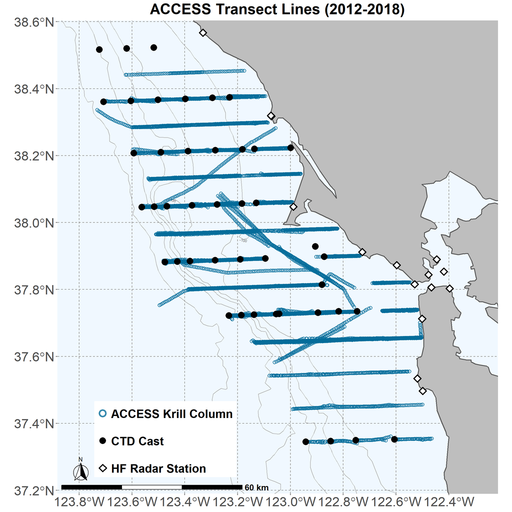

```r
# All Lines Together
 p_AllLines <-  dataGamm %>%
    dplyr::select(Line, Lat,Long) %>%
    unique() %>%
    ggplot() +
    geom_sf(data = world,color=NA,fill=NA) +
    # add 200m contour
    geom_contour(data = bf,
                 aes(x=x, y=y, z=z),
                 breaks=c(-100,-200,-400,-800,-1600),
                 size=c(0.4),
                 colour="darkgrey", show.legend = FALSE) +
    geom_text_contour(data = bf, aes(x=x, y=y,z = z),breaks=c(-100,-200,-400,-800,-1600),
                      show.legend = FALSE, size = 2.2, alpha = .6, nudge_y = -.002) +
    geom_point(aes(Long,Lat,color="ACCESS Krill Column"),alpha=.8,stroke=0.9,size=2, shape=21,show.legend = TRUE) +
    geom_sf(data = world, size=.75,fill="grey") +
    geom_point(data=dataCTD, aes(x=Long, y=Lat, alpha="CTD Cast"),size=5)+
    geom_point(data=hfRadar_DF,
             aes(x=Long, y=Lat, shape = ID),color="black",size=3.5,stroke=1.5,
             fill = 'white') +
    scale_color_manual(values = c("ACCESS Krill Column"="#046C9A")) +
    scale_alpha_manual(values=c("CTD Cast"=1))+
    scale_shape_manual(values = c("HF Radar Station" = 23))+
    coord_sf(xlim = c(min(dataGamm$Long,na.rm = TRUE)-.15,
                      max(dataGamm$Long,na.rm = TRUE)+.25),
             ylim = c(min(dataGamm$Lat,na.rm = TRUE)-.15,
                      max(dataGamm$Lat,na.rm = TRUE)+.15), expand = FALSE) +
  annotation_scale(location = "bl", width_hint = 0.5, text_face = "bold",
                   text_col = "black",text_cex = 1.2) +
  annotation_north_arrow(location = "bl",
                         which_north = "true",
                         pad_x = unit(0.25, "in"),
                         pad_y = unit(0.25, "in"),
                         style = north_arrow_fancy_orienteering) +
    xlab("Longitude") +
    ylab("Latitude") +
    ggtitle("ACCESS Transect Lines (2012-2018)") +
    guides(color = guide_legend(order=1, override.aes = list(size=4, stroke=2)))+
    theme(panel.grid.major = element_line(color = gray(.5), linetype = "dashed", size = 0.5),
          panel.background = element_rect(fill = "aliceblue"),
          axis.title = element_blank(),
        axis.text = element_text( face="bold", size=22),
        plot.title = element_text(face="bold", size=25,hjust = 0.5),
        plot.subtitle = element_text( face="bold", size=18,hjust = 0.5),
        plot.caption = element_text( face="bold", size=14,hjust = 0),
        legend.position= c(0.245,0.115),
        legend.key = element_blank(),
        legend.box.background = element_rect(color = "white",fill="white"),
        legend.background = element_rect(color = "white",fill="white"),
        legend.text = element_text(face="bold", size=20),
        legend.title = element_blank())
p_AllLines
```

# Methods

## FTLE

A recent study in the same region (Gough et al 2016) found good agreement between SST and LCS during summer months (though the relationship fell apart during strong upwelling-favorable winds in late March). Here we use the 2 integration durations used in that study (1 and 5 days), the integration used in Fahlbusch et al 2021 (2 days) as well as a longer period for comparison (10 days) to examine the interaction between krill density and distribution and Lagrangian Coherent Structures (LCS) during summer months. **Here we see a comparison of the 4 integration times for a single survey transect line in 2012.**

```r
#### Setup ####
tzOffset <- "Etc/GMT+7" # all surveys are on the same one
FTLEdatapath <- "./dataRaw/FTLE/"
degreeBuffer <- .25
quantilePlot <- seq(.3,.95,by=.07)

c = "ACC1207" # Cruise
l = "6" # Line
  data_Sub <- dataGamm %>%
    dplyr::filter(Cruise == c, Line == l)
# Subset full resolution acoustics data for this cruise/line
d_Sub_Line <- acoustics_DF_FTLE_W600 %>%
  dplyr::filter(Cruise == c, Line == l)
# Create a column summary for this line
lineSum <- d_Sub_Line %>%
  mutate(minCID = min(as.integer(d_Sub_Line$ColumnID))) %>%
  group_by(ColumnID) %>%
  summarise(dttz = first(dttz),
            Lat = first(Lat),
            Long = first(Long),
            ftle24=first(ftle24_L),
            ftle48=first(ftle48_L),
            ftle120=first(ftle120_L),
            ftle240=first(ftle240_L),
            botDepth = first(BotDepth),
            KrillBiomass = sum(KrillBiomass),
            numWith = sum(KrillBiomass>0),
            density = if_else(numWith > 0, mean(KrillDensity[KrillDensity>0]),0),
            logDensity = if_else(density==0, -4,log(density)),
            x = (as.integer(first(ColumnID))-first(minCID))*200)

# Load the FTLE data
FTLE_stack24 <- stack(paste0(FTLEdatapath,c,"_FTLE_24Hrs.nc"),
                      varname = "FTLE")
FTLE_stack48 <- stack(paste0(FTLEdatapath,c,"_FTLE_48Hrs.nc"),
                      varname = "FTLE")
FTLE_stack120 <- stack(paste0(FTLEdatapath,c,"_FTLE_120Hrs.nc"),
                      varname = "FTLE")
FTLE_stack240 <- stack(paste0(FTLEdatapath,c,"_FTLE_240Hrs.nc"),
                      varname = "FTLE")
# FTLE PLOT
ftle_alpha <- function(n, flatten, scrunch) {
  c(scales::rescale(exp((1:flatten)/scrunch), to = c(0.25, 1)), rep(1, n - flatten))
}

#Determine Quantiles for FTLE Color Scaling
qFTLE24 <- quantile(FTLE_stack24, probs = quantilePlot,na.rm=TRUE)
qSumFTLE24 <- as.data.frame(summary(qFTLE24)) %>%
  dplyr::select(-Var1) %>%
  dplyr::filter(grepl("Mean",Freq)) %>%
  group_by(Var2) %>%
  mutate(Means = unlist(str_split(Freq,":"))[2]) %>%
  ungroup()
qFTLE48 <- quantile(FTLE_stack48, probs = quantilePlot,na.rm=TRUE)
qSumFTLE48 <- as.data.frame(summary(qFTLE48)) %>%
  dplyr::select(-Var1) %>%
  dplyr::filter(grepl("Mean",Freq)) %>%
  group_by(Var2) %>%
  mutate(Means = unlist(str_split(Freq,":"))[2]) %>%
  ungroup()
qFTLE120 <- quantile(FTLE_stack120, probs = quantilePlot,na.rm=TRUE)
qSumFTLE120 <- as.data.frame(summary(qFTLE120)) %>%
  dplyr::select(-Var1) %>%
  dplyr::filter(grepl("Mean",Freq)) %>%
  group_by(Var2) %>%
  mutate(Means = unlist(str_split(Freq,":"))[2]) %>%
  ungroup()
qFTLE240 <- quantile(FTLE_stack240,probs = quantilePlot,na.rm=TRUE)
qSumFTLE240 <- as.data.frame(summary(qFTLE240)) %>%
  dplyr::select(-Var1) %>%
  dplyr::filter(grepl("Mean",Freq)) %>%
  group_by(Var2) %>%
  mutate(Means = unlist(str_split(Freq,":"))[2]) %>%
  ungroup()

#### Maps ####

  # create a dataframe of each integration
  FTLE_spdf24 <- as(mean(FTLE_stack24[[first(d_Sub_Line$lineMinI):first(d_Sub_Line$lineMaxI)]]), "SpatialPixelsDataFrame")
  FTLE_df24 <- as.data.frame(FTLE_spdf24)
  colnames(FTLE_df24) <- c("FTLE", "x", "y")
  FTLE_spdf48 <- as(mean(FTLE_stack48[[first(d_Sub_Line$lineMinI):first(d_Sub_Line$lineMaxI)]]), "SpatialPixelsDataFrame")
  FTLE_df48 <- as.data.frame(FTLE_spdf48)
  colnames(FTLE_df48) <- c("FTLE", "x", "y")
  FTLE_spdf120 <- as(mean(FTLE_stack120[[first(d_Sub_Line$lineMinI):first(d_Sub_Line$lineMaxI)]]), "SpatialPixelsDataFrame")
  FTLE_df120 <- as.data.frame(FTLE_spdf120)
  colnames(FTLE_df120) <- c("FTLE", "x", "y")
  FTLE_spdf240 <- as(mean(FTLE_stack240[[first(d_Sub_Line$lineMinI):first(d_Sub_Line$lineMaxI)]]), "SpatialPixelsDataFrame")
  FTLE_df240 <- as.data.frame(FTLE_spdf240)
  colnames(FTLE_df240) <- c("FTLE", "x", "y")

# 24 ####
p24 <- ggplot() +
  geom_sf(data = world,color=NA,fill=NA) +
  geom_raster(data = FTLE_df24[complete.cases(FTLE_df24),],
                mapping = aes(x, y, fill = FTLE)) +
  labs(x="", y="") +
  scale_fill_gradientn(colors = viridis(option = "plasma", n = 40,
                                        alpha = ftle_alpha(40, 8, 8)),
                       limits=c(0, 1.25),
                       breaks = c(0,0.6,1.2),
                       values = scales::rescale(
                           c(0,as.numeric(qSumFTLE24$Means[1:9]))),
                       oob=scales::squish,
                       na.value = NA,
                       name = expression(atop( bold('FTLE (24 hr)'),
                                               bold(day^bold({bold("-1")})) )) ) +
  # add 100m and 200m contours
  ggplot2::geom_contour(data = bf_Sub,
                        mapping = aes(x=x, y=y, z=z),
                        breaks=c(-100),
                        size=c(0.4),
                        colour="darkgray", show.legend = FALSE) +
  metR::geom_text_contour(data = bf_Sub, mapping = aes(x=x,y=y,z=z),
                          breaks = c(-100), show.legend = FALSE,
                          size = 2.5, alpha = .8, nudge_y = -.002,
                          color="lightgrey") +
  ggplot2::geom_contour(data = bf_Sub,
                        mapping = aes(x=x, y=y, z=z),
                        breaks=c(-200),
                        size=c(0.4),
                        colour="darkgray", show.legend = FALSE) +
  metR::geom_text_contour(data = bf_Sub, mapping = aes(x=x,y=y,z=z),
                          breaks = c(-200),
                          label.placement = label_placement_n(5),
                          show.legend = FALSE, size = 2.5, alpha = .8,
                          nudge_y = -.002, color="lightgrey") +
  geom_point(data = data_Sub,
             mapping = aes(Long,Lat, color=KrillDensity_MeanNonZero ),#
             size=5,shape=15, show.legend = TRUE,
             alpha = 1, fill="black") +
  geom_label(data = lineSum[c(1,length(lineSum$ColumnID) ),],
             mapping = aes(Long,Lat),label=c("Start","End"),
             size=2.5,nudge_y = .02)+
  scale_color_gradient(name = expression(atop(bold("Krill Density"),
                                              bold(log[e](g/m^3)) )),
                       low="white",
                       high="magenta",
                       na.value = "white",
                       limits = c(0,4),
                       breaks=seq(0,5,1),
                       oob=scales::squish) +
  geom_sf(data = world, size=1.25,fill="lightgrey",color="grey") +
  geom_sf(data = world, size=1.25,fill="lightgrey",color="grey") +
  coord_sf(xlim = c(min(d_Sub_Line$Long,na.rm = TRUE)-degreeBuffer,
                    max(d_Sub_Line$Long,na.rm = TRUE)+degreeBuffer),
           ylim = c(min(d_Sub_Line$Lat,na.rm = TRUE)-0.35,
                    max(d_Sub_Line$Lat,na.rm = TRUE)+0.35),
           expand = FALSE) +
  theme_classic() +
  annotation_scale(location = "br", width_hint = 0.5, text_face = "bold", text_col = "grey") +
  annotation_north_arrow(location = "br",
                         which_north = "true",
                         pad_x = unit(0.25, "in"),
                         pad_y = unit(0.25, "in"),
                         style = north_arrow_fancy_orienteering(line_col = "grey",
                                                                fill = c("white", "black"),
                                                                text_col = "grey"  ) ) +
  xlab("Longitude") +
  ylab("Latitude") +
  guides(color = guide_colourbar(order=1,direction = 'horizontal' ,
                                 title.position = "top",
                                 title.hjust = .5,
                                 label.position = "bottom"),
         fill = guide_colourbar(order=2,direction = 'horizontal',
                                title.position = "top",
                                title.hjust = .5,
                                label.position = "bottom")) +
  theme(panel.grid.major = element_line(color = gray(.5),
                                        linetype = "dashed", size = 0.5),
        panel.background = element_rect(fill = "aliceblue"),
        axis.text = element_text(face="bold", size=10),
        axis.title = element_blank(),
        legend.text = element_text(face="bold", size=10),
        legend.position = c(.125,.2),
        legend.box = 'vertical',
        legend.title = element_text(face="bold", size=12),
        legend.box.background = element_rect(color="white",
                                             size=2.5, fill="white"),
        legend.spacing.y = unit(0.025, "cm"),
        # adds a buffer on the sides so the plot is centered
        plot.margin=margin(t = 0.5, r = 1, b = 0, l = 0.25, "cm"),
        plot.title = element_text(face="bold", size=24, hjust = 0.5),
        plot.subtitle = element_text(face="bold", size=20, hjust = 0.5))
```

```r
# 48 ####
p48 <- ggplot()+
  geom_sf(data = world,color=NA,fill=NA) +
  geom_raster(data = FTLE_df48[complete.cases(FTLE_df48),],
              mapping = aes(x, y, fill = FTLE)) +
  labs(x="", y="") +
  scale_fill_gradientn(colors = viridis(option = "plasma", n = 40,
                                        alpha = ftle_alpha(40, 8, 8)),
                       values = scales::rescale(
                         c(0,as.numeric(qSumFTLE48$Means[1:9]))),
                       limits=c(0, 1),
                       breaks = c(0,0.5,1),
                       oob=scales::squish,
                       na.value = NA,
                       name = expression(atop( bold('FTLE (48 hr)'),
                                               bold(day^bold({bold("-1")})) )) ) +
  # add 100m and 200m contours
  ggplot2::geom_contour(data = bf_Sub,
                        mapping = aes(x=x, y=y, z=z),
                        breaks=c(-100),
                        size=c(0.4),
                        colour="darkgray", show.legend = FALSE) +
  metR::geom_text_contour(data = bf_Sub, mapping = aes(x=x,y=y,z=z),
                          breaks = c(-100), show.legend = FALSE,
                          size = 2.5, alpha = .8, nudge_y = -.002,
                          color="lightgrey") +
  ggplot2::geom_contour(data = bf_Sub,
                        mapping = aes(x=x, y=y, z=z),
                        breaks=c(-200),
                        size=c(0.4),
                        colour="darkgray", show.legend = FALSE) +
  metR::geom_text_contour(data = bf_Sub, mapping = aes(x=x,y=y,z=z),
                          breaks = c(-200),
                          label.placement = label_placement_n(5),
                          show.legend = FALSE, size = 2.5, alpha = .8,
                          nudge_y = -.002, color="lightgrey") +
  geom_point(data = data_Sub,
             mapping = aes(Long,Lat, color=KrillDensity_MeanNonZero ),
             size=5,shape=15, show.legend = TRUE,
             alpha = 1, fill="black") +
  geom_label(data = lineSum[c(1,length(lineSum$ColumnID) ),],
             mapping = aes(Long,Lat),label=c("Start","End"),
             size=2.5,nudge_y = .02)+
  scale_color_gradient(name = expression(atop(bold("Krill Density"),
                                              bold(log[e](g/m^3)) )),
                       low="white",
                       high="magenta",
                       na.value = "white",
                       limits = c(0,4),
                       breaks=seq(0,5,1),
                       oob=scales::squish) +
  geom_sf(data = world, size=1.25,fill="lightgrey",color="grey") +
  coord_sf(xlim = c(min(d_Sub_Line$Long,na.rm = TRUE)-degreeBuffer,
                    max(d_Sub_Line$Long,na.rm = TRUE)+degreeBuffer),
           ylim = c(min(d_Sub_Line$Lat,na.rm = TRUE)-0.35,
                    max(d_Sub_Line$Lat,na.rm = TRUE)+0.35),
           expand = FALSE) +
  theme_classic() +
  annotation_scale(location = "br", width_hint = 0.5, text_face = "bold", text_col = "grey") +
  annotation_north_arrow(location = "br",
                         which_north = "true",
                         pad_x = unit(0.25, "in"),
                         pad_y = unit(0.25, "in"),
                         style = north_arrow_fancy_orienteering(line_col = "grey",
                                                                fill = c("white", "black"),
                                                                text_col = "grey"  ) ) +
  xlab("Longitude") +
  ylab("Latitude") +
  guides(color = guide_colourbar(order=1,direction = 'horizontal' ,
                                 title.position = "top",
                                 title.hjust = .5,
                                 label.position = "bottom"),
         fill = guide_colourbar(order=2,direction = 'horizontal',
                                title.position = "top",
                                title.hjust = .5,
                                label.position = "bottom")) +
  theme(panel.grid.major = element_line(color = gray(.5),
                                        linetype = "dashed", size = 0.5),
        panel.background = element_rect(fill = "aliceblue"),
        axis.text = element_text(face="bold", size=10),
        axis.title = element_blank(),
        legend.text = element_text(face="bold", size=10),
        legend.position = c(.125,.2),
        legend.box = 'vertical',
        legend.title = element_text(face="bold", size=12),
        legend.box.background = element_rect(color="white",
                                             size=2.5, fill="white"),
        legend.spacing.y = unit(0.025, "cm"),
        # adds a buffer on the sides so the plot is centered
        plot.margin=margin(t = 0.5, r = 1, b = 0, l = 0.25, "cm"),
        plot.title = element_text(face="bold", size=24, hjust = 0.5),
        plot.subtitle = element_text(face="bold", size=20, hjust = 0.5))

# 120 ####
p120 <- ggplot()+
  geom_sf(data = world,color=NA,fill=NA) +
  geom_raster(data = FTLE_df120[complete.cases(FTLE_df120),],
             mapping = aes(x, y, fill = FTLE)) +
  labs(x="", y="") +
  scale_fill_gradientn(colors = viridis(option = "plasma", n = 40,
                                        alpha = ftle_alpha(40, 8, 8)),
                       values = scales::rescale(
                         c(0,as.numeric(qSumFTLE120$Means[1:9]))),
                       limits=c(0, .8),
                       breaks = c(0,.4,.8),
                       oob=scales::squish,
                       na.value = NA,
                       name = expression(atop( bold('FTLE (120 hr)'),
                                               bold(day^bold({bold("-1")})) )) ) +
  # add 100m and 200m contours
  ggplot2::geom_contour(data = bf_Sub,
                        mapping = aes(x=x, y=y, z=z),
                        breaks=c(-100),
                        size=c(0.4),
                        colour="darkgray", show.legend = FALSE) +
  metR::geom_text_contour(data = bf_Sub, mapping = aes(x=x,y=y,z=z),
                          breaks = c(-100), show.legend = FALSE,
                          size = 2.5, alpha = .8, nudge_y = -.002,
                          color="lightgrey") +
  ggplot2::geom_contour(data = bf_Sub,
                        mapping = aes(x=x, y=y, z=z),
                        breaks=c(-200),
                        size=c(0.4),
                        colour="darkgray", show.legend = FALSE) +
  metR::geom_text_contour(data = bf_Sub, mapping = aes(x=x,y=y,z=z),
                          breaks = c(-200),
                          label.placement = label_placement_n(5),
                          show.legend = FALSE, size = 2.5, alpha = .8,
                          nudge_y = -.002, color="lightgrey") +
  geom_point(data = data_Sub,
             mapping = aes(Long,Lat, color=KrillDensity_MeanNonZero ),
             size=5,shape=15, show.legend = TRUE,
             alpha = 1, fill="black") +
  geom_label(data = lineSum[c(1,length(lineSum$ColumnID) ),],
             mapping = aes(Long,Lat),label=c("Start","End"),
             size=2.5,nudge_y = .02)+
  scale_color_gradient(name = expression(atop(bold("Krill Density"),
                                              bold(log[e](g/m^3)) )),
                       low="white",
                       high="magenta",
                       na.value = "white",
                       limits = c(0,4),
                       breaks=seq(0,5,1),
                       oob=scales::squish) +
  geom_sf(data = world, size=1.25,fill="lightgrey",color="grey") +
  coord_sf(xlim = c(min(d_Sub_Line$Long,na.rm = TRUE)-degreeBuffer,
                    max(d_Sub_Line$Long,na.rm = TRUE)+degreeBuffer),
           ylim = c(min(d_Sub_Line$Lat,na.rm = TRUE)-0.35,
                    max(d_Sub_Line$Lat,na.rm = TRUE)+0.35),
           expand = FALSE) +
  theme_classic() +
  annotation_scale(location = "br", width_hint = 0.5, text_face = "bold", text_col = "grey") +
  annotation_north_arrow(location = "br",
                         which_north = "true",
                         pad_x = unit(0.25, "in"),
                         pad_y = unit(0.25, "in"),
                         style = north_arrow_fancy_orienteering(line_col = "grey",
                                                                fill = c("white", "black"),
                                                                text_col = "grey"  ) ) +
  xlab("Longitude") +
  ylab("Latitude") +
  guides(color = guide_colourbar(order=1,direction = 'horizontal' ,
                                 title.position = "top",
                                 title.hjust = .5,
                                 label.position = "bottom"),
         fill = guide_colourbar(order=2,direction = 'horizontal',
                                title.position = "top",
                                title.hjust = .5,
                                label.position = "bottom")) +
  theme(panel.grid.major = element_line(color = gray(.5),
                                        linetype = "dashed", size = 0.5),
        panel.background = element_rect(fill = "aliceblue"),
        axis.text = element_text(face="bold", size=10),
        axis.title = element_blank(),
        legend.text = element_text(face="bold", size=10),
        legend.position = c(.125,.2),
        legend.box = 'vertical',
        legend.title = element_text(face="bold", size=12),
        legend.box.background = element_rect(color="white",
                                             size=2.5, fill="white"),
        legend.spacing.y = unit(0.025, "cm"),
        # adds a buffer on the sides so the plot is centered
        plot.margin=margin(t = 0.5, r = 1, b = 0, l = 0.25, "cm"),
        plot.title = element_text(face="bold", size=24, hjust = 0.5),
        plot.subtitle = element_text(face="bold", size=20, hjust = 0.5))
```

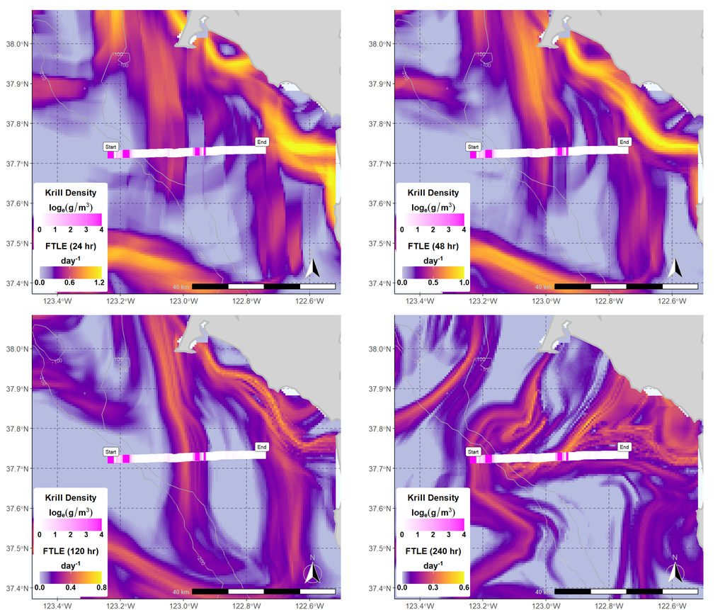

```r
# 240 ####
p240 <- ggplot()+
  geom_sf(data = world,color=NA,fill=NA) +
  geom_raster(data = FTLE_df240[complete.cases(FTLE_df240),],
              mapping = aes(x, y, fill = FTLE)) +
  labs(x="", y="") +
  scale_fill_gradientn(colors = viridis(option = "plasma", n = 40,
                                        alpha = ftle_alpha(40, 8, 8)),
                       values = scales::rescale(
                         c(0,as.numeric(qSumFTLE240$Means[1:9]))),
                       limits=c(0, .6),
                       breaks = c(0,.3,.6),
                       oob=scales::squish,
                       na.value = NA,
                       name = expression(atop( bold('FTLE (240 hr)'),
                                               bold(day^bold({bold("-1")})) )) ) +
  # add 100m and 200m contours
  ggplot2::geom_contour(data = bf_Sub,
                        mapping = aes(x=x, y=y, z=z),
                        breaks=c(-100),
                        size=c(0.4),
                        colour="darkgray", show.legend = FALSE) +
  metR::geom_text_contour(data = bf_Sub, mapping = aes(x=x,y=y,z=z),
                          breaks = c(-100), show.legend = FALSE,
                          size = 2.5, alpha = .8, nudge_y = -.002,
                          color="lightgrey") +
  ggplot2::geom_contour(data = bf_Sub,
                        mapping = aes(x=x, y=y, z=z),
                        breaks=c(-200),
                        size=c(0.4),
                        colour="darkgray", show.legend = FALSE) +
  metR::geom_text_contour(data = bf_Sub, mapping = aes(x=x,y=y,z=z),
                          breaks = c(-200),
                          label.placement = label_placement_n(5),
                          show.legend = FALSE, size = 2.5, alpha = .8,
                          nudge_y = -.002, color="lightgrey") +
  geom_point(data = data_Sub,
             mapping = aes(Long,Lat, color=KrillDensity_MeanNonZero ),#
             size=5,shape=15, show.legend = TRUE,
             alpha = 1, fill="black") +
  geom_label(data = lineSum[c(1,length(lineSum$ColumnID) ),],
             mapping = aes(Long,Lat),label=c("Start","End"),
             size=2.5,nudge_y = .02)+
  scale_color_gradient(name = expression(atop(bold("Krill Density"),
                                              bold(log[e](g/m^3)) )),
                       low="white",
                       high="magenta",
                       na.value = "white",
                       limits = c(0,4),
                       breaks=seq(0,5,1),
                       oob=scales::squish) +
  geom_sf(data = world, size=1.25,fill="lightgrey",color="grey") +
  coord_sf(xlim = c(min(d_Sub_Line$Long,na.rm = TRUE)-degreeBuffer,
                    max(d_Sub_Line$Long,na.rm = TRUE)+degreeBuffer),
           ylim = c(min(d_Sub_Line$Lat,na.rm = TRUE)-0.35,
                    max(d_Sub_Line$Lat,na.rm = TRUE)+0.35),
           expand = FALSE) +
  theme_classic() +
  annotation_scale(location = "br", width_hint = 0.5, text_face = "bold", text_col = "grey") +
  annotation_north_arrow(location = "br",
                         which_north = "true",
                         pad_x = unit(0.25, "in"),
                         pad_y = unit(0.25, "in"),
                         style = north_arrow_fancy_orienteering(line_col = "grey",
                                                                fill = c("white", "black"),
                                                                text_col = "grey"  ) ) +
  xlab("Longitude") +
  ylab("Latitude") +
  guides(color = guide_colourbar(order=1,direction = 'horizontal' ,
                                 title.position = "top",
                                 title.hjust = .5,
                                 label.position = "bottom"),
         fill = guide_colourbar(order=2,direction = 'horizontal',
                                title.position = "top",
                                title.hjust = .5,
                                label.position = "bottom")) +
  theme(panel.grid.major = element_line(color = gray(.5),
                                        linetype = "dashed", size = 0.5),
        panel.background = element_rect(fill = "aliceblue"),
        axis.text = element_text(face="bold", size=10),
        axis.title = element_blank(),
        legend.text = element_text(face="bold", size=10),
        legend.position = c(.125,.2),
        legend.box = 'vertical',
        legend.title = element_text(face="bold", size=12),
        legend.box.background = element_rect(color="white",
                                             size=2.5, fill="white"),#
        legend.spacing.y = unit(0.025, "cm"),
        # adds a buffer on the sides so the plot is centered
        plot.margin=margin(t = 0.5, r = 1, b = 0, l = 0.25, "cm"),
        plot.title = element_text(face="bold", size=24, hjust = 0.5),
        plot.subtitle = element_text(face="bold", size=20, hjust = 0.5))

# Plot All ####
pMapH <- ggarrange(p24,p48,p120,p240,
                   ncol=2, nrow = 2,
                   align = "hv")
pMapH
```

FTLE data is in hourly increments (due to the temporal resolution of the HF Radar surface current measurements), and some survey transect lines spanned multiple FTLE measurement increments (mean = 3.02, 90% have 5 or less layers). To avoid introducing artificial jumps in measurement values at hourly changes, for this analysis we calculated a spatial mean of the FTLE layers for each line.

## Krill

Krill acoustic data from the ACCESS Cruises are summarized into 200m long x 5m deep cells. (Note: The first 5m are not analyzed, so the top of the most shallow cell in any column is 5m.) To match the spatial resolution of the FTLE data, we combine acoustic grid cells into 600m Columns and calculate several summary statistics of each column for analysis. These include:

- Maximum Krill Density (max in any cell within a column)
- Mean Density of Cells with Krill
- Geometric Mean Density of Cells with Krill (10^(mean(log10(Krill Density))))

**Here we see the distribution of krill in relation the FTLE along the transect line for all 4 integration times.** *Note: this is the same transect line shown in the figure above.*

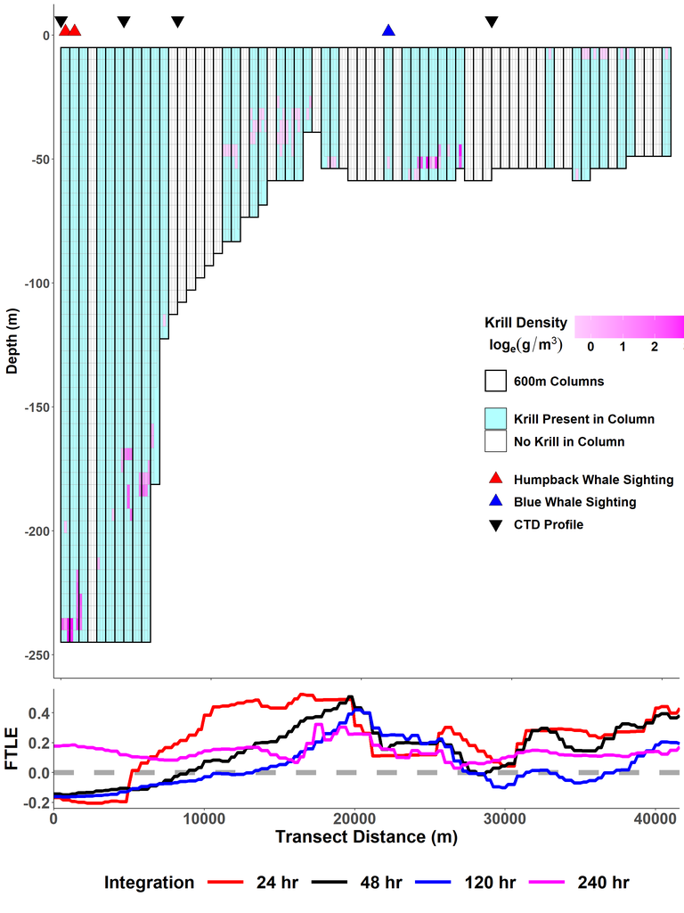

```r
# Create  a plot showing the acoustics data and how they were processed
c = "ACC1207"
l = "6"

markerSize <- 5.5
markerBump <- 0.021
# Subset 600m resolution acoustics data for this cruise/line
data_Sub <- dataGamm %>%
  dplyr::filter(Cruise == c, Line == l)
# Subset CTD data for this cruise/line
cast_Sub <- dataCTD %>%
  dplyr::filter(Cruise == c, Line == l)
# Subset full resolution acoustics data for this cruise/line
d_Sub_Line <- acoustics_DF_FTLE_W600 %>%
  dplyr::filter(Cruise == c, Line == l)
# Create a column summary for this line
lineSum <- d_Sub_Line %>%
  mutate(minCID = min(as.integer(d_Sub_Line$ColumnID))) %>%
  group_by(ColumnID) %>%
  summarise(dttz = first(dttz),
            Lat = first(Lat),
            Long = first(Long),
            ftle24=first(ftle24_L),
            ftle48=first(ftle48_L),
            ftle120=first(ftle120_L),
            ftle240=first(ftle240_L),
            botDepth = first(BotDepth),
            KrillBiomass = sum(KrillBiomass),
            numWith = sum(KrillBiomass>0),
            density = if_else(numWith > 0, mean(KrillDensity[KrillDensity>0]),0),
            logDensity = if_else(density==0, -8,log10(density)),
            x = (as.integer(first(ColumnID))-first(minCID))*200)
#### Transect Plot ####
# Create a matrix of the vertical
x = matrix(nrow = (2+length(unique(as.integer(d_Sub_Line$CellID)))),
           ncol = length(unique(as.integer(d_Sub_Line$ColumnID))),
           byrow=FALSE)
for(ii in 1:length(unique(as.integer(d_Sub_Line$ColumnID)))){
  numNA <- nrow(x)- (2+max(as.integer(d_Sub_Line$CellID[d_Sub_Line$ColumnID==unique(as.integer(d_Sub_Line$ColumnID))[ii]])))
  if(numNA>0){
    x[,ii] <- c(NA, NA, d_Sub_Line$KrillDensity[d_Sub_Line$ColumnID==unique(as.integer(d_Sub_Line$ColumnID))[ii]], rep(NA, numNA))
  } else {
    x[,ii] <- c(NA, NA, d_Sub_Line$KrillDensity[d_Sub_Line$ColumnID==unique(as.integer(d_Sub_Line$ColumnID))[ii]])
  }
}
# Create a raster from transect values
r <- raster(ncol=ncol(x),nrow=nrow(x))
raster::values(r) <- x
bb <- extent(0, (ncol(x)-1)*200,(nrow(x)-1)*-5, 0)
extent(r) <- bb
r <- setExtent(r, bb, keepres=TRUE)

rSPDF <- as(r, "SpatialPixelsDataFrame")
r_df <- as.data.frame(rSPDF)
colnames(r_df) <- c("KrillDensity", "x", "y")
r_df <- arrange(r_df, x, -y)
# add x and y back onto d_sub_Line
d_Sub_Line <- cbind(d_Sub_Line,x=r_df$x,y=r_df$y)

d_sub600 <- d_Sub_Line %>%
  group_by(Col600) %>%
  summarize(minX = min(x)-100,
            maxX= max(x)+100,
            minY = min(y)+5, # adjust to represent the top of the column
            maxY= 0,
            Krill = if_else(sum(KrillBiomass)>0,1,0))

cast_SubSum <- cast_Sub %>%
  mutate(x = c(0,4180,7763,28661))

whaleCTD <- d_sub600 %>%
  left_join(dplyr::select(data_Sub,Col600, HUWH, BLWH), by = "Col600" )


ylim.prim <- c(round(min(r_df$y))-10, 0)
ylim.sec <- c(1000,0)

b <- diff(ylim.prim)/diff(ylim.sec)
a <- ylim.prim[1] - b*ylim.sec[1]

# Main Plot

p1 <- ggplot() +
  # geom_line(data= lineSum,aes(x=x,y=-botDepth),size=1.25)+
  geom_rect(data=d_sub600, aes(xmin = minX, xmax = maxX, ymin = minY-2.5, ymax = -5,
                               alpha="600m Columns"),color="black", fill="white") +
  geom_rect(data=d_sub600, aes(xmin = minX, xmax = maxX, ymin = minY-2.5, ymax = -5,
                               fill=as.factor(Krill)),color="black") +
  scale_fill_manual(name = NULL, values = c("1"="#b3ffff","0"="white"),
                    labels = c("Krill Present in Column", "No Krill in Column"),
                    guide = guide_legend(order=3,direction = 'vertical')
                    )+
  new_scale_fill() +
  geom_tile(data=r_df,aes(x=x, y=y+5,fill=log(KrillDensity)),color="darkgrey", alpha=0.95) +
  scale_fill_gradient(name = expression(atop(bold("Krill Density"),
                                             bold(log[e](g/m^3)) )),
                      low="#FFCCFF",
                      high="magenta",
                      na.value = NA,
                      limits = c(-0.5,3),
                      breaks=seq(0,3,1),
                      oob=scales::squish) +
  geom_rect(data=d_sub600, aes(xmin = minX, xmax = maxX, ymin = minY-2.5, ymax = -5,
                               alpha="600m Columns"),color="black", fill=NA, size = 0.75) +
  scale_alpha_manual(name=NULL, values=c("600m Columns"=0.1)) +
  geom_point(data= whaleCTD[whaleCTD$HUWH == 1,], aes(y=1.5,x=minX+300, shape = "Humpback Whale Sighting"),
             fill = "red", color="black", size=markerSize)+
  geom_point(data= whaleCTD[whaleCTD$BLWH == 1,], aes(y=1.5,x=minX+300, shape = "Blue Whale Sighting"),
             fill = "blue", color="black", size=markerSize)+
  geom_point(data=cast_SubSum, aes(y=6,x=x, shape = "CTD Profile"),
             fill = "black", color="black", size=markerSize)+
  scale_shape_manual(name = NULL, values = c("Humpback Whale Sighting" = 24,
                                          "Blue Whale Sighting" = 24,
                                          "CTD Profile" = 25) )+
  scale_y_continuous(limits=c(round(min(r_df$y))-5, 6), expand = c(0.025,0))+
  scale_x_continuous(expand = c(0.0115,0.00005),limits=c(-1,(max(r_df$x))-800 )
                     )+
  xlab("Transect Distance (km)")+ ylab("Depth (m)")+
  guides(
         fill = guide_colourbar(order=1,direction = 'horizontal',title.position = "left",
                                title.hjust = .5,label.position = "bottom"),
         alpha = guide_legend(order=2,direction = 'vertical'
                              ),
         shape = guide_legend(order=4,direction = 'vertical',
                              override.aes = list(fill = c("red", "blue", "black"))  )) +
  theme_classic()+
  theme(legend.position= c(.85,.375),#"bottom",
        legend.direction = "horizontal",#"
        legend.title = element_text(face="bold", size=18),
        legend.text = element_text(face="bold", size=16),
        legend.key.size = unit(1, "cm"),
        legend.spacing.y= unit(0.15, "cm"),
        plot.title = element_text(face="bold", size=24,hjust = 0.5),
        plot.subtitle = element_text( face="bold", size=22,hjust = 0.5),
        plot.caption = element_text( face="bold", size=18,hjust = 0),
        axis.title = element_text(face="bold", size=18),
        axis.text = element_text(face="bold", size=16),
        axis.title.x = element_blank(),
        axis.text.x = element_blank()
        )
p2<- ggplot()+
      geom_hline(yintercept=0, linetype = 'dashed', size=3,color="darkgrey")+
      geom_line(data = lineSum,aes(x=x,y=ftle24,color="24 hr"),size=2)+
      geom_line(data = lineSum,aes(x=x,y=ftle48,color="48 hr"),size=2)+
      geom_line(data = lineSum,aes(x=x,y=ftle120,color="120 hr"),size=2)+
      geom_line(data = lineSum,aes(x=x,y=ftle240,color="240 hr"),size=2)+
      scale_color_manual(name= "Integration",breaks = c("24 hr", "48 hr", "120 hr","240 hr"),values = c("red", "black", "blue", "magenta"))+
      xlab("Transect Distance (m)")+ ylab("FTLE")+
      scale_x_continuous(expand = c(0,0))+
      theme_classic()+
      theme(legend.position="bottom",
            legend.title = element_text(face="bold", size=22),
            legend.text = element_text(face="bold", size=22),
            legend.key.size = unit(2, "cm"),
            plot.title = element_text(face="bold", size=24,hjust = 0.5),
            plot.subtitle = element_text( face="bold", size=22,hjust = 0.5),
            plot.caption = element_text( face="bold", size=18,hjust = 0),
            axis.title = element_text(face="bold", size=22),
            axis.text = element_text(face="bold", size=20),
            axis.title.y.right = element_text(face="bold", size=18, color="grey"),
            axis.text.y.right = element_text(face="bold", size=10, color="grey"))
tP<-ggarrange(p1,p2,nrow=2,align = c("hv"), heights = c(.75,.25) )
tP
```

## Cetacean Data

In conjunction with the krill transect surveys, cetacean sightings were also recorded. Due to the nature of the transects, sightings were not investigated further (i.e. the ship did not break off the line to pursue groups of whales) resulting in a large number of unidentified whales. For this reason, we excluded outliers in distance from ship to reduce potential bias in location accuracy of sightings (i.e. > .5 nm from ship) and excluded sightings where the species could not be verified. Additionally, due to the low sample size of Gray, and Minke whales, they are excluded from our analysis. **80% of sightings were between 0 and 0.5 nm from the ship.**

```r
cetacean_DF_FTLE  %>%
  dplyr::filter(Type == "ACC") %>%
  mutate(Distance = if_else(DisFrShipNm <= 0.5, "0-0.5 nm","0.5+ nm")) %>%
  group_by(SpCode, Distance) %>%
  summarise(NumSightings = n())
```

| SpCode | Distance | NumSightings |
| --- | --- | --- |
| BLWH | 0-0.5 nm | 140 |
| BLWH | 0.5+ nm | 37 |
| FIWH | 0-0.5 nm | 8 |
| GRWH | 0-0.5 nm | 5 |
| HUWH | 0-0.5 nm | 750 |
| HUWH | 0.5+ nm | 139 |
| MIWH | 0-0.5 nm | 2 |
| UNWH | 0-0.5 nm | 340 |
| UNWH | 0.5+ nm | 138 |

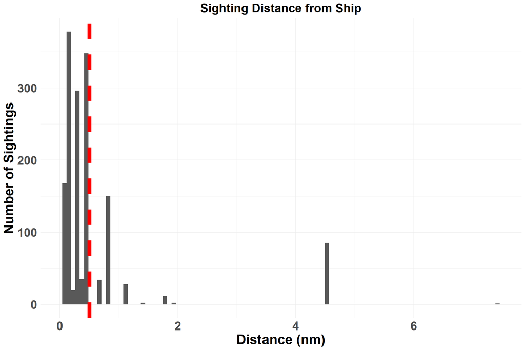

```r
ggplot()+
  geom_histogram(data=cetacean_DF_FTLE ,aes(x=DisFrShipNm),bins=100)+
  geom_vline(xintercept = 0.5, color='red',linetype=2,size=3)+
  ggtitle("Sighting Distance from Ship")+
  xlab("Distance (nm)")+
  ylab("Number of Sightings") +
  theme_minimal()+
  theme(axis.title = element_text(face="bold", size=22),
        axis.text = element_text( face="bold", size=20),
        plot.title = element_text(face="bold", size=20,hjust = 0.5),
        plot.subtitle = element_text( face="bold", size=18,hjust = 0.5),
        plot.caption = element_text( face="bold", size=16,hjust = 1),
        legend.text = element_text(face="bold", size=20),
        legend.title = element_text(face="bold", size=24))
```

To examine the relationship between cetacean presence and FTLE, we joined the cetacean sighting data to the 600 meter columns used in the krill analysis (denoting cetacean presence for each species). Columns without cetacean sightings were labeled as absences, and we fitted a logistic regression using the presence/absence for each column as the response.

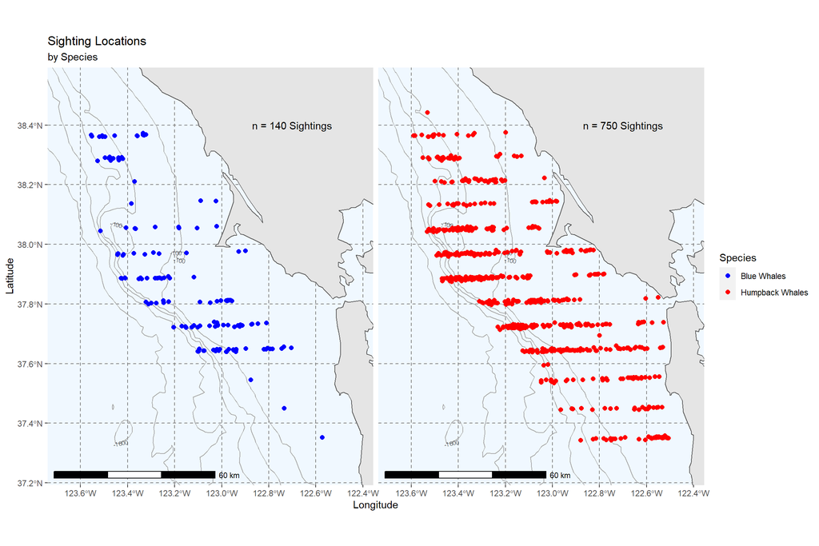

```r
cetacean_Sum <- cetacean_Sub %>%
  group_by(SpCode) %>%
  summarise(NumSightings = n())

ggplot()+
  geom_sf(data = world) +
  coord_sf(xlim = c(min(cetacean_Sub$SightLong,na.rm = TRUE)-.15,
                    max(cetacean_Sub$SightLong,na.rm = TRUE)+.15),
           ylim = c(min(cetacean_Sub$SightLat,na.rm = TRUE)-.15,
                    max(cetacean_Sub$SightLat,na.rm = TRUE)+.15), expand = FALSE) +
  # add 200m contour
  geom_contour(data = bf,
               aes(x=x, y=y, z=z),
               breaks=c(-100,-200,-400,-800,-1600),
               size=c(0.4),
               colour="darkgrey", show.legend = FALSE) +
  geom_text_contour(data = bf, aes(x=x, y=y,z = z),breaks=c(-100,-200,-400,-800,-1600),
                    show.legend = FALSE, size = 2.2, alpha = .6, nudge_y = -.002) +
  geom_point(data=cetacean_Sub, aes(x=SightLong,y=SightLat,color=SpCode, group=SpCode),size=2) +
  geom_text(data=cetacean_Sum, aes( label = paste0("n = ", NumSightings, " Sightings"), group=SpCode ), x=-122.7,y=38.4)+
  scale_color_manual(name= "Species", values=c("BLWH"="blue", "HUWH"= "red"),labels=c("BLWH"="Blue Whales", "HUWH"="Humpback Whales") ) +
  annotation_scale(location = "bl", width_hint = 0.5) +
  xlab("Longitude") +
  ylab("Latitude") +
  ggtitle("Sighting Locations",subtitle = "by Species") +
  theme(panel.grid.major = element_line(color = gray(.5), linetype = "dashed", size = 0.5),
        panel.background = element_rect(fill = "aliceblue"),
        strip.background = element_blank(),
  strip.text.x = element_blank()) +
  facet_grid(~SpCode)
```

## Oceanographic Data

In-situ oceanographic observations were recorded from periodic CTD casts along the krill transect lines. Because the CTD casts were not continuous and were spread out over several nautical miles, we analyzed them separately from the krill data. We extracted the FTLE for the specific time/location of the CTD cast, and calculated several summary metrics from the casts for analysis (Density at 0, 10 20, 30, 40 and 50 meters). To allow for comparability across samples, we excluded CTD casts with a maximum cast depth of less than 50 meters.

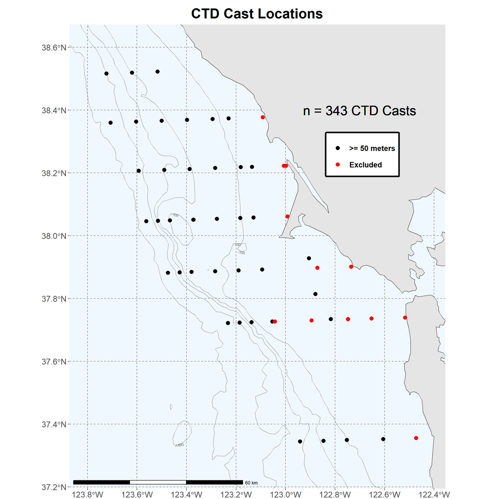

```r
  castSummary_FTLE %>%
  mutate(keep = if_else(maxDepth>=50,">= 50 meters","Excluded")) %>%
     ggplot() +
    geom_sf(data = world) +
    coord_sf(xlim = c(min(dataCTD$Long,na.rm = TRUE)-.15, max(dataCTD$Long,na.rm = TRUE)+.25),
             ylim = c(min(dataCTD$Lat,na.rm = TRUE)-.15, max(dataCTD$Lat,na.rm = TRUE)+.15), expand = FALSE) +
# add 200m contour
  geom_contour(data = bf,
               aes(x=x, y=y, z=z),
               breaks=c(-100,-200,-400,-800,-1600),
               # breaks=c(-200),
               size=c(0.4),
               colour="darkgrey", show.legend = FALSE) +
  geom_text_contour(data = bf, aes(x=x, y=y,z = z),breaks=c(-100,-200,-400,-800,-1600),
                    show.legend = FALSE, size = 2.2, alpha = .6, nudge_y = -.002) +
    geom_point(aes(y=Lat,x=Long,color=keep),size=3)+
    geom_text(  label = paste0("n = ", length(dataCTD$ID_Date), " CTD Casts"), x=-122.7,y=38.4,size=8)+
  scale_color_manual(name=NULL, values = c(">= 50 meters" = "black","Excluded" = "red" ))+
  annotation_scale(location = "bl", width_hint = 0.5) +
  xlab("Longitude") +
  ylab("Latitude") +
  ggtitle("CTD Cast Locations") +
  theme(panel.grid.major = element_line(color = gray(.5), linetype = "dashed", size = 0.5),
        panel.background = element_rect(fill = "aliceblue"),
        legend.key = element_blank(),
        axis.text = element_text(face="bold", size=14),
        axis.title = element_blank(),
        legend.text = element_text(face="bold", size=13),
        legend.position = c(.78,.72),
        legend.box = 'vertical',
        legend.key.size = unit(1, "cm"),
        legend.title = element_text(face="bold", size=12),
        legend.box.background = element_rect(color="black",
                                             size=2.5, fill="white"),
        plot.margin=margin(t = 0.5, r = 1, b = 0, l = 0.25, "cm"),
        plot.title = element_text(face="bold", size=24, hjust = 0.5),
        plot.subtitle = element_text(face="bold", size=20, hjust = 0.5))
```

# Analysis

## Oceanographic Expression of FTLE Features

### 1. Do surface FTLE features correspond to density differences and if so, to what depth?

#### GLMM (Seawater Density ~ FTLE)

We examined seawater density (Sigma-T) for depths between the surface and 50 meters (at 10 meter increments). Sigma-T (units of kg/m^3) is an estimate of the potential density of seawater, minus 1000 kg/m^3.

*Overall, we found a significant relationship between Seawater Density and FTLE at both the surface and at 10 meters for the 120 hour integration window, and while not significant, the slopes for all other integration windows were positive for the surface and 10 meter depths.*

*The relationship changes as depth increases beyond 10 meters. For depths of 20-50 meters, the coefficients for the 24 and 48 hour integration windows are negative and the relationship is significant for the 24 hour window. For the 120 and 240 hour integration windows, the coefficients are all positive though not significant, and follow a pattern diminishing slope estimate with increasing depth.*

##### Density at Surface

```r
## 24
ssSigmaT_GLMM24 <- glmer(SigmaTheta0m ~ ftle24 +
                           (1|Year) + (1|Season) + (1|Line),
                           family = gaussian,
                           data = dataCTD %>% dplyr::filter(!is.na(ftle24),
                                                            !is.na(SigmaTheta0m)))
anovassSigmaT_GLMM24 <- car::Anova(ssSigmaT_GLMM24, type=2)
## 48
ssSigmaT_GLMM48 <- glmer(SigmaTheta0m ~ ftle48 +
                           (1|Year) + (1|Season) + (1|Line),
                           family = gaussian,
                           data = dataCTD %>% dplyr::filter(!is.na(ftle48),
                                                            !is.na(SigmaTheta0m)))
anovassSigmaT_GLMM48 <- car::Anova(ssSigmaT_GLMM48, type=2)
## 120
ssSigmaT_GLMM120 <- glmer(SigmaTheta0m ~ ftle120 +
                           (1|Year) + (1|Season) + (1|Line),
                           family = gaussian,
                           data = dataCTD %>% dplyr::filter(!is.na(ftle120),
                                                            !is.na(SigmaTheta0m)))
anovassSigmaT_GLMM120 <- car::Anova(ssSigmaT_GLMM120, type=2)
## 240
ssSigmaT_GLMM240 <- glmer(SigmaTheta0m ~ ftle240 +
                           (1|Year) + (1|Season) + (1|Line),
                           family = gaussian,
                           data = dataCTD %>% dplyr::filter(!is.na(ftle240),
                                                            !is.na(SigmaTheta0m)))
anovassSigmaT_GLMM240 <- car::Anova(ssSigmaT_GLMM240, type=2)

tssSigmaT_GLMM <- data.frame(Model = c(rep("GLMM Sea Surface Sigma Theta",4) ),
                       FTLE_Integration = c("24","48","120", "240"),
                       Slope = c(round(ssSigmaT_GLMM24@beta[2],4),
                                 round(ssSigmaT_GLMM48@beta[2],4),
                                 round(ssSigmaT_GLMM120@beta[2],4),
                                 round(ssSigmaT_GLMM240@beta[2],4)
                                 ),
                       Intercept = c(round(ssSigmaT_GLMM24@beta[1],4),
                                     round(ssSigmaT_GLMM48@beta[1],4),
                                     round(ssSigmaT_GLMM120@beta[1],4),
                                     round(ssSigmaT_GLMM240@beta[1],4)
                                 ),
                       pValue = c(round(anovassSigmaT_GLMM24$`Pr(>Chisq)`,5),
                                  round(anovassSigmaT_GLMM48$`Pr(>Chisq)`,5),
                                  round(anovassSigmaT_GLMM120$`Pr(>Chisq)`,5),
                                  round(anovassSigmaT_GLMM240$`Pr(>Chisq)`,5)
                                  )
)
tssSigmaT_GLMM
```

| Model | FTLE_Integration | Slope | Intercept | pValue |
| --- | --- | --- | --- | --- |
| GLMM Sea Surface Sigma Theta | 24 | 0.0545 | 25.1968 | 0.52495 |
| GLMM Sea Surface Sigma Theta | 48 | 0.1262 | 25.1935 | 0.18939 |
| GLMM Sea Surface Sigma Theta | 120 | 0.3704 | 25.2281 | 0.00143 |
| GLMM Sea Surface Sigma Theta | 240 | 0.2889 | 25.2592 | 0.05069 |

##### Density at 10 meters

```r
## 24
D10_GLMM24 <- glmer(SigmaTheta10m ~ ftle24 +
                           (1|Year) + (1|Season) + (1|Line),
                           family = gaussian,
                           data = dataCTD %>% dplyr::filter(!is.na(ftle24),
                                                            !is.na(SigmaTheta10m)))
anovaD10_GLMM24 <- car::Anova(D10_GLMM24, type=2)
## 48
D10_GLMM48 <- glmer(SigmaTheta10m ~ ftle48 +
                           (1|Year) + (1|Season) + (1|Line),
                           family = gaussian,
                           data = dataCTD %>% dplyr::filter(!is.na(ftle48),
                                                            !is.na(SigmaTheta10m)))
anovaD10_GLMM48 <- car::Anova(D10_GLMM48, type=2)
## 120
D10_GLMM120 <- glmer(SigmaTheta10m ~ ftle120 +
                           (1|Year) + (1|Season) + (1|Line),
                           family = gaussian,
                           data = dataCTD %>% dplyr::filter(!is.na(ftle120),
                                                            !is.na(SigmaTheta10m)))
anovaD10_GLMM120 <- car::Anova(D10_GLMM120, type=2)
## 240
D10_GLMM240 <- glmer(SigmaTheta10m ~ ftle240 +
                           (1|Year) + (1|Season) + (1|Line),
                           family = gaussian,
                           data = dataCTD %>% dplyr::filter(!is.na(ftle240),
                                                            !is.na(SigmaTheta10m)))
anovaD10_GLMM240 <- car::Anova(D10_GLMM240, type=2)

tD10_GLMM <- data.frame(Model = c(rep("GLMM Sigma Theta at 10 meters",4) ),
                       FTLE_Integration = c("24","48","120", "240"),
                       Slope = c(round(D10_GLMM24@beta[2],4),
                                 round(D10_GLMM48@beta[2],4),
                                 round(D10_GLMM120@beta[2],4),
                                 round(D10_GLMM240@beta[2],4)
                                 ),
                       Intercept = c(round(D10_GLMM24@beta[1],4),
                                     round(D10_GLMM48@beta[1],4),
                                     round(D10_GLMM120@beta[1],4),
                                     round(D10_GLMM240@beta[1],4)
                                 ),
                       pValue = c(round(anovaD10_GLMM24$`Pr(>Chisq)`,5),
                                  round(anovaD10_GLMM48$`Pr(>Chisq)`,5),
                                  round(anovaD10_GLMM120$`Pr(>Chisq)`,5),
                                  round(anovaD10_GLMM240$`Pr(>Chisq)`,5)
                                  )
)
tD10_GLMM
```

| Model | FTLE_Integration | Slope | Intercept | pValue |
| --- | --- | --- | --- | --- |
| GLMM Sigma Theta at 10 meters | 24 | 0.0162 | 25.3555 | 0.84426 |
| GLMM Sigma Theta at 10 meters | 48 | 0.1176 | 25.3452 | 0.19947 |
| GLMM Sigma Theta at 10 meters | 120 | 0.3391 | 25.3673 | 0.00154 |
| GLMM Sigma Theta at 10 meters | 240 | 0.2454 | 25.3987 | 0.06771 |

##### Density at 20 meters

```r
## 24
D20_GLMM24 <- glmer(SigmaTheta20m ~ ftle24 +
                           (1|Year) + (1|Season) + (1|Line),
                           family = gaussian,
                           data = dataCTD %>% dplyr::filter(!is.na(ftle24),
                                                            !is.na(SigmaTheta20m)))
anovaD20_GLMM24 <- car::Anova(D20_GLMM24, type=2)
## 48
D20_GLMM48 <- glmer(SigmaTheta20m ~ ftle48 +
                           (1|Year) + (1|Season) + (1|Line),
                           family = gaussian,
                           data = dataCTD %>% dplyr::filter(!is.na(ftle48),
                                                            !is.na(SigmaTheta20m)))
anovaD20_GLMM48 <- car::Anova(D20_GLMM48, type=2)
## 120
D20_GLMM120 <- glmer(SigmaTheta20m ~ ftle120 +
                           (1|Year) + (1|Season) + (1|Line),
                           family = gaussian,
                           data = dataCTD %>% dplyr::filter(!is.na(ftle120),
                                                            !is.na(SigmaTheta20m)))
anovaD20_GLMM120 <- car::Anova(D20_GLMM120, type=2)
## 240
D20_GLMM240 <- glmer(SigmaTheta20m ~ ftle240 +
                           (1|Year) + (1|Season) + (1|Line),
                           family = gaussian,
                           data = dataCTD %>% dplyr::filter(!is.na(ftle240),
                                                            !is.na(SigmaTheta20m)))
anovaD20_GLMM240 <- car::Anova(D20_GLMM240, type=2)

tD20_GLMM <- data.frame(Model = c(rep("GLMM Sigma Theta at 20 meters",4) ),
                       FTLE_Integration = c("24","48","120", "240"),
                       Slope = c(round(D20_GLMM24@beta[2],4),
                                 round(D20_GLMM48@beta[2],4),
                                 round(D20_GLMM120@beta[2],4),
                                 round(D20_GLMM240@beta[2],4)
                                 ),
                       Intercept = c(round(D20_GLMM24@beta[1],4),
                                     round(D20_GLMM48@beta[1],4),
                                     round(D20_GLMM120@beta[1],4),
                                     round(D20_GLMM240@beta[1],4)
                                 ),
                       pValue = c(round(anovaD20_GLMM24$`Pr(>Chisq)`,5),
                                  round(anovaD20_GLMM48$`Pr(>Chisq)`,5),
                                  round(anovaD20_GLMM120$`Pr(>Chisq)`,5),
                                  round(anovaD20_GLMM240$`Pr(>Chisq)`,5)
                                  )
)
tD20_GLMM
```

| Model | FTLE_Integration | Slope | Intercept | pValue |
| --- | --- | --- | --- | --- |
| GLMM Sigma Theta at 20 meters | 24 | -0.1717 | 25.5993 | 0.01471 |
| GLMM Sigma Theta at 20 meters | 48 | -0.0335 | 25.5727 | 0.66812 |
| GLMM Sigma Theta at 20 meters | 120 | 0.1635 | 25.5819 | 0.06603 |
| GLMM Sigma Theta at 20 meters | 240 | 0.1611 | 25.6163 | 0.14203 |

##### Density at 30 meters

```r
## 24
D30_GLMM24 <- glmer(SigmaTheta30m ~ ftle24 +
                           (1|Year) + (1|Season) + (1|Line),
                           family = gaussian,
                           data = dataCTD %>% dplyr::filter(!is.na(ftle24),
                                                            !is.na(SigmaTheta30m)))
anovaD30_GLMM24 <- car::Anova(D30_GLMM24, type=2)
## 48
D30_GLMM48 <- glmer(SigmaTheta30m ~ ftle48 +
                           (1|Year) + (1|Season) + (1|Line),
                           family = gaussian,
                           data = dataCTD %>% dplyr::filter(!is.na(ftle48),
                                                            !is.na(SigmaTheta30m)))
anovaD30_GLMM48 <- car::Anova(D30_GLMM48, type=2)
## 120
D30_GLMM120 <- glmer(SigmaTheta30m ~ ftle120 +
                           (1|Year) + (1|Season) + (1|Line),
                           family = gaussian,
                           data = dataCTD %>% dplyr::filter(!is.na(ftle120),
                                                            !is.na(SigmaTheta30m)))
anovaD30_GLMM120 <- car::Anova(D30_GLMM120, type=2)
## 240
D30_GLMM240 <- glmer(SigmaTheta30m ~ ftle240 +
                           (1|Year) + (1|Season) + (1|Line),
                           family = gaussian,
                           data = dataCTD %>% dplyr::filter(!is.na(ftle240),
                                                            !is.na(SigmaTheta30m)))
anovaD30_GLMM240 <- car::Anova(D30_GLMM240, type=2)

tD30_GLMM <- data.frame(Model = c(rep("GLMM Sigma Theta at 30 meters",4) ),
                       FTLE_Integration = c("24","48","120", "240"),
                       Slope = c(round(D30_GLMM24@beta[2],4),
                                 round(D30_GLMM48@beta[2],4),
                                 round(D30_GLMM120@beta[2],4),
                                 round(D30_GLMM240@beta[2],4)
                                 ),
                       Intercept = c(round(D30_GLMM24@beta[1],4),
                                     round(D30_GLMM48@beta[1],4),
                                     round(D30_GLMM120@beta[1],4),
                                     round(D30_GLMM240@beta[1],4)
                                 ),
                       pValue = c(round(anovaD30_GLMM24$`Pr(>Chisq)`,5),
                                  round(anovaD30_GLMM48$`Pr(>Chisq)`,5),
                                  round(anovaD30_GLMM120$`Pr(>Chisq)`,5),
                                  round(anovaD30_GLMM240$`Pr(>Chisq)`,5)
                                  )
)
tD30_GLMM
```

| Model | FTLE_Integration | Slope | Intercept | pValue |
| --- | --- | --- | --- | --- |
| GLMM Sigma Theta at 30 meters | 24 | -0.1743 | 25.7775 | 0.00438 |
| GLMM Sigma Theta at 30 meters | 48 | -0.0826 | 25.7596 | 0.22734 |
| GLMM Sigma Theta at 30 meters | 120 | 0.0776 | 25.7667 | 0.31705 |
| GLMM Sigma Theta at 30 meters | 240 | 0.1415 | 25.7955 | 0.15451 |

##### Density at 40 meters

```r
## 24
D40_GLMM24 <- glmer(SigmaTheta40m ~ ftle24 +
                           (1|Year) + (1|Season) + (1|Line),
                           family = gaussian,
                           data = dataCTD %>% dplyr::filter(!is.na(ftle24),
                                                            !is.na(SigmaTheta40m)))
anovaD40_GLMM24 <- car::Anova(D40_GLMM24, type=2)
## 48
D40_GLMM48 <- glmer(SigmaTheta40m ~ ftle48 +
                           (1|Year) + (1|Season) + (1|Line),
                           family = gaussian,
                           data = dataCTD %>% dplyr::filter(!is.na(ftle48),
                                                            !is.na(SigmaTheta40m)))
anovaD40_GLMM48 <- car::Anova(D40_GLMM48, type=2)
## 120
D40_GLMM120 <- glmer(SigmaTheta40m ~ ftle120 +
                           (1|Year) + (1|Season) + (1|Line),
                           family = gaussian,
                           data = dataCTD %>% dplyr::filter(!is.na(ftle120),
                                                            !is.na(SigmaTheta40m)))
anovaD40_GLMM120 <- car::Anova(D40_GLMM120, type=2)
## 240
D40_GLMM240 <- glmer(SigmaTheta40m ~ ftle240 +
                           (1|Year) + (1|Season) + (1|Line),
                           family = gaussian,
                           data = dataCTD %>% dplyr::filter(!is.na(ftle240),
                                                            !is.na(SigmaTheta40m)))
anovaD40_GLMM240 <- car::Anova(D40_GLMM240, type=2)

tD40_GLMM <- data.frame(Model = c(rep("GLMM Sigma Theta at 40 meters",4) ),
                       FTLE_Integration = c("24","48","120", "240"),
                       Slope = c(round(D40_GLMM24@beta[2],4),
                                 round(D40_GLMM48@beta[2],4),
                                 round(D40_GLMM120@beta[2],4),
                                 round(D40_GLMM240@beta[2],4)
                                 ),
                       Intercept = c(round(D40_GLMM24@beta[1],4),
                                     round(D40_GLMM48@beta[1],4),
                                     round(D40_GLMM120@beta[1],4),
                                     round(D40_GLMM240@beta[1],4)
                                 ),
                       pValue = c(round(anovaD40_GLMM24$`Pr(>Chisq)`,5),
                                  round(anovaD40_GLMM48$`Pr(>Chisq)`,5),
                                  round(anovaD40_GLMM120$`Pr(>Chisq)`,5),
                                  round(anovaD40_GLMM240$`Pr(>Chisq)`,5)
                                  )
)
tD40_GLMM
```

| Model | FTLE_Integration | Slope | Intercept | pValue |
| --- | --- | --- | --- | --- |
| GLMM Sigma Theta at 40 meters | 24 | -0.1408 | 25.8791 | 0.00939 |
| GLMM Sigma Theta at 40 meters | 48 | -0.0418 | 25.8598 | 0.49531 |
| GLMM Sigma Theta at 40 meters | 120 | 0.0912 | 25.8721 | 0.19005 |
| GLMM Sigma Theta at 40 meters | 240 | 0.1367 | 25.8948 | 0.12618 |

##### Density at 50 meters

```r
## 24
D50_GLMM24 <- glmer(SigmaTheta50m ~ ftle24 +
                           (1|Year) + (1|Season) + (1|Line),
                           family = gaussian,
                           data = dataCTD %>% dplyr::filter(!is.na(ftle24),
                                                            !is.na(SigmaTheta50m)))
anovaD50_GLMM24 <- car::Anova(D50_GLMM24, type=2)
## 48
D50_GLMM48 <- glmer(SigmaTheta50m ~ ftle48 +
                           (1|Year) + (1|Season) + (1|Line),
                           family = gaussian,
                           data = dataCTD %>% dplyr::filter(!is.na(ftle48),
                                                            !is.na(SigmaTheta50m)))
anovaD50_GLMM48 <- car::Anova(D50_GLMM48, type=2)
## 120
D50_GLMM120 <- glmer(SigmaTheta50m ~ ftle120 +
                           (1|Year) + (1|Season) + (1|Line),
                           family = gaussian,
                           data = dataCTD %>% dplyr::filter(!is.na(ftle120),
                                                            !is.na(SigmaTheta50m)))
anovaD50_GLMM120 <- car::Anova(D50_GLMM120, type=2)
## 240
D50_GLMM240 <- glmer(SigmaTheta50m ~ ftle240 +
                           (1|Year) + (1|Season) + (1|Line),
                           family = gaussian,
                           data = dataCTD %>% dplyr::filter(!is.na(ftle240),
                                                            !is.na(SigmaTheta50m)))
anovaD50_GLMM240 <- car::Anova(D50_GLMM240, type=2)

tD50_GLMM <- data.frame(Model = c(rep("GLMM Sigma Theta at 50 meters",4) ),
                       FTLE_Integration = c("24","48","120", "240"),
                       Slope = c(round(D50_GLMM24@beta[2],4),
                                 round(D50_GLMM48@beta[2],4),
                                 round(D50_GLMM120@beta[2],4),
                                 round(D50_GLMM240@beta[2],4)
                                 ),
                       Intercept = c(round(D50_GLMM24@beta[1],4),
                                     round(D50_GLMM48@beta[1],4),
                                     round(D50_GLMM120@beta[1],4),
                                     round(D50_GLMM240@beta[1],4)
                                 ),
                       pValue = c(round(anovaD50_GLMM24$`Pr(>Chisq)`,5),
                                  round(anovaD50_GLMM48$`Pr(>Chisq)`,5),
                                  round(anovaD50_GLMM120$`Pr(>Chisq)`,5),
                                  round(anovaD50_GLMM240$`Pr(>Chisq)`,5)
                                  )
)
tD50_GLMM
```

| Model | FTLE_Integration | Slope | Intercept | pValue |
| --- | --- | --- | --- | --- |
| GLMM Sigma Theta at 50 meters | 24 | -0.1295 | 25.9706 | 0.00539 |
| GLMM Sigma Theta at 50 meters | 48 | -0.0282 | 25.9507 | 0.59256 |
| GLMM Sigma Theta at 50 meters | 120 | 0.0674 | 25.9653 | 0.26360 |
| GLMM Sigma Theta at 50 meters | 240 | 0.0962 | 25.9782 | 0.21549 |

##### Supplemental Figure 1

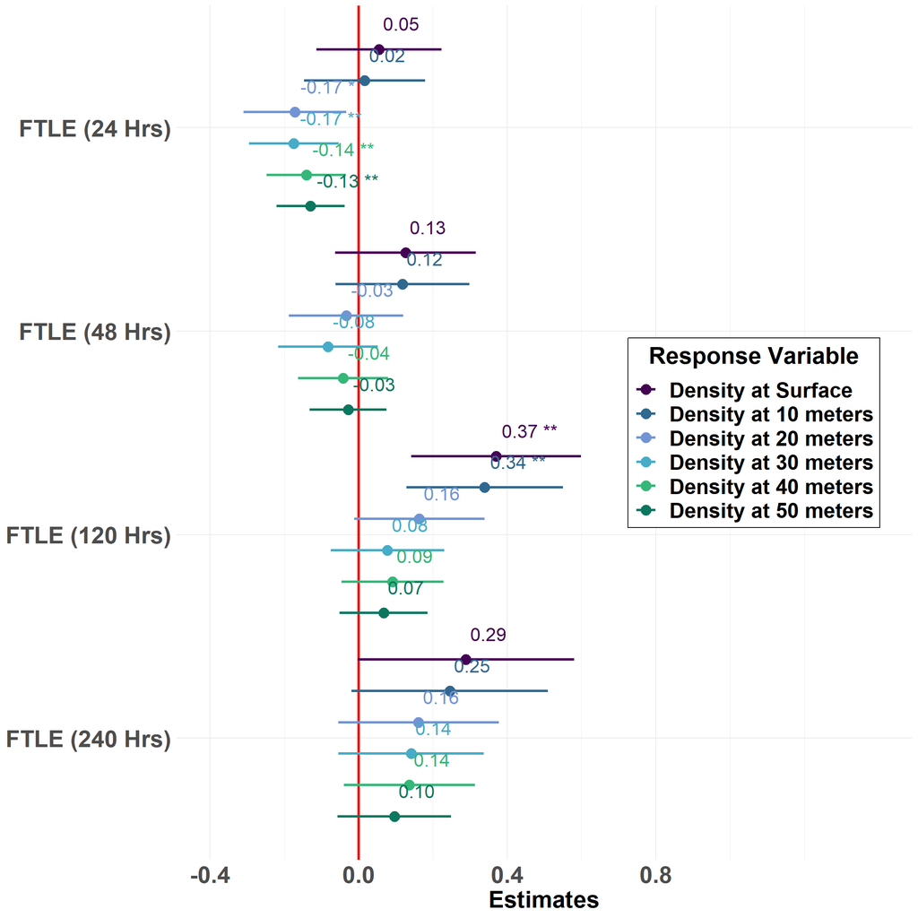

```r
   p_ctdDensityAllv2 <- plot_models(D50_GLMM24,D50_GLMM48,
                                 D50_GLMM120,D50_GLMM240,
                                 D40_GLMM24,D40_GLMM48,
                                 D40_GLMM120,D40_GLMM240,
                                 D30_GLMM24,D30_GLMM48,
                                 D30_GLMM120,D30_GLMM240,
                                 D20_GLMM24,D20_GLMM48,
                                 D20_GLMM120,D20_GLMM240,
                                 D10_GLMM24,D10_GLMM48,
                                 D10_GLMM120,D10_GLMM240,
                                 ssSigmaT_GLMM24,ssSigmaT_GLMM48,
                                 ssSigmaT_GLMM120,ssSigmaT_GLMM240,
                                 vline.color = "red",show.p=TRUE,show.values=TRUE, spacing = 0.925,
                                 show.legend = TRUE, dot.size = 4.5, value.size = 6, line.size = 1.2,
                                 axis.labels = c("FTLE (240 Hrs)","FTLE (120 Hrs)","FTLE (48 Hrs)","FTLE (24 Hrs)")) +
    scale_y_continuous(breaks=c(-0.4,0,0.4,0.8), limits = c(-0.4,1.4)) +
    # ggtitle("Water Density (SigmaT) ~ FTLE")+
    theme_minimal() +
    theme(axis.title = element_text(face="bold", size=22),
          axis.text = element_text( face="bold", size=22),
          plot.title = element_text(face="bold", size=25,hjust = 0.5),
          plot.subtitle = element_text( face="bold", size=20,hjust = 0.5),
          plot.caption = element_text( face="bold", size=12,hjust = 0),
          legend.position = c(0.785,0.5),
          legend.direction = "vertical",
          legend.key.size = unit(0.8,"cm"),
          legend.background = element_rect(fill="white",color="black"),
          legend.text = element_text(face="bold", size=20),
          legend.title = element_text(face="bold", size=22, hjust = 0.5))


  p_ctdDensityAllv2$guides$colour$title <- "Response Variable"
  p_ctdDensityAllv2$data$group <- factor(x = c(rep("Density at 50 meters",4), rep("Density at 40 meters",4), rep("Density at 30 meters",4), rep("Density at 20 meters",4), rep("Density at 10 meters",4), rep("Density at Surface",4)), levels = c("Density at 50 meters","Density at 40 meters","Density at 30 meters",  "Density at 20 meters","Density at 10 meters", "Density at Surface") )
  p_ctdDensityAllv2 <- p_ctdDensityAllv2 +
    scale_color_manual(values=c("Density at 50 meters" =  "#0B775E",
                                "Density at 40 meters" =  "#35B779FF",
                                "Density at 30 meters" =  "#46ACC8",
                                "Density at 20 meters" =  "#7294D4",
                                "Density at 10 meters" =  "#31688EFF",
                                "Density at Surface" =  "#440154FF"
    )
    )
  p_ctdDensityAllv2
```

##### Figure 3A

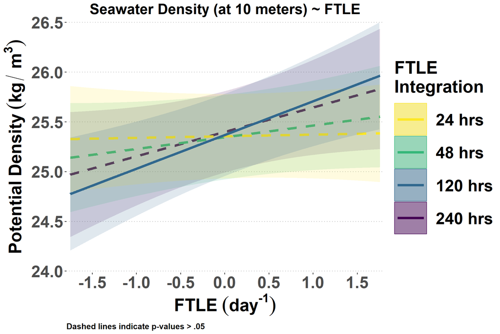

```r
testSetp_CTD24 <- data.frame(ftle24 = seq(-2, 2, length.out = 1000))
# This function outputs the predicted values in Response scale
testSetp_CTD24$fit <- predict(D10_GLMM24,newdata = testSetp_CTD24,
                              type = "response", re.form=~0,se.fit = TRUE)
# Calculate the standard errors of the predicted values
X24 <- model.matrix(~ ftle24, testSetp_CTD24)
#calculate the covariance matrix of the model
V24 <- vcov(D10_GLMM24, full = TRUE)
# take the square root of the diagonal elements to obtain the standard errors
se24 <- sqrt(diag(X24 %*% V24 %*% t(X24)))
# Convert the Log Standard errors into the Response scale
testSetp_CTD24$lwr <- testSetp_CTD24$fit - 1.96 * se24
testSetp_CTD24$upr <- testSetp_CTD24$fit + 1.96 * se24
testSetp_CTD24$model <- "24 hrs"

testSetp_CTD48 <- data.frame(ftle48 = seq(-2, 2, length.out = 1000))
# This function outputs the predicted values in Response scale
testSetp_CTD48$fit <- predict(D10_GLMM48,newdata = testSetp_CTD48,
                              type = "response", re.form=~0,se.fit = TRUE)
# Calculate the standard errors of the predicted values
X48 <- model.matrix(~ ftle48, testSetp_CTD48)
#calculate the covariance matrix of the model
V48 <- vcov(D10_GLMM48, full = TRUE)
# take the square root of the diagonal elements to obtain the standard errors
se48 <- sqrt(diag(X48 %*% V48 %*% t(X48)))
# Convert the Log Standard errors into the Response scale
testSetp_CTD48$lwr <- testSetp_CTD48$fit - 1.96 * se48
testSetp_CTD48$upr <- testSetp_CTD48$fit + 1.96 * se48
testSetp_CTD48$model <- "48 hrs"

testSetp_CTD120 <- data.frame(ftle120 = seq(-2, 2, length.out = 1000))
# This function outputs the predicted values in Response scale
testSetp_CTD120$fit <- predict(D10_GLMM120, newdata = testSetp_CTD120,
                               type = "response", re.form=~0,se.fit = TRUE)
# Calculate the standard errors of the predicted values
X120 <- model.matrix(~ ftle120, testSetp_CTD120)
#calculate the covariance matrix of the model
V120 <- vcov(D10_GLMM120, full = TRUE)
# take the square root of the diagonal elements to obtain the standard errors
se120 <- sqrt(diag(X120 %*% V120 %*% t(X120)))
# Convert the Log Standard errors into the Response scale
testSetp_CTD120$lwr <- testSetp_CTD120$fit - 1.96 * se120
testSetp_CTD120$upr <- testSetp_CTD120$fit + 1.96 * se120
testSetp_CTD120$model <- "120 hrs"

testSetp_CTD240 <- data.frame(ftle240 = seq(-2, 2, length.out = 1000))
# This function outputs the predicted values in Response scale
testSetp_CTD240$fit <- predict(D10_GLMM240,newdata = testSetp_CTD240,
                               type = "response", re.form=~0,se.fit = TRUE)
# Calculate the standard errors of the predicted values
X240 <- model.matrix(~ ftle240, testSetp_CTD240)
#calculate the covariance matrix of the model
V240 <- vcov(D10_GLMM240, full = TRUE)
# take the square root of the diagonal elements to obtain the standard errors
se240 <- sqrt(diag(X240 %*% V240 %*% t(X240)))

# Convert the Log Standard errors into the Response scale
testSetp_CTD240$lwr <- testSetp_CTD240$fit - 1.96 * se240
testSetp_CTD240$upr <- testSetp_CTD240$fit + 1.96 * se240
testSetp_CTD240$model <- "240 hrs"

ggplot() +
  geom_ribbon(data=testSetp_CTD240,aes(x=ftle240,ymin = lwr, ymax = upr,
                                       color = NULL,fill=model), alpha = .15) +
  geom_line(data=testSetp_CTD240,aes(x=ftle240,y = fit, color=model),
            size = 2, linetype=2)+
  geom_ribbon(data=testSetp_CTD48,aes(x=ftle48,ymin = lwr, ymax = upr,
                                      color = NULL,fill=model), alpha = .15) +
  geom_line(data=testSetp_CTD48,aes(x=ftle48,y = fit, color=model),
            size = 2, linetype=2)+
  geom_ribbon(data=testSetp_CTD24,aes(x=ftle24,ymin = lwr, ymax = upr,
                                      color = NULL,fill=model), alpha = .15) +
  geom_line(data=testSetp_CTD24,aes(x=ftle24,y = fit, color=model),
            size = 2, linetype=2)+
  geom_ribbon(data=testSetp_CTD120,aes(x=ftle120,ymin = lwr, ymax = upr,
                                       color = NULL,fill=model), alpha = .15) +
  geom_line(data=testSetp_CTD120,aes(x=ftle120,y = fit, color=model),
            size = 2, linetype=1)+
  scale_color_manual(name= "FTLE\nIntegration",
                       breaks=c("24 hrs","48 hrs","120 hrs","240 hrs"),
                       values=c( "24 hrs" =     "#FDE725FF",
                               "48 hrs" = "#35B779FF",
                               "120 hrs" =  "#31688EFF",
                               "240 hrs" = "#440154FF"
                               )) +
  scale_fill_manual(name= "FTLE\nIntegration",
                      breaks=c("24 hrs","48 hrs","120 hrs","240 hrs"),
                       values=c( "24 hrs" =     "#FDE725FF",
                               "48 hrs" = "#35B779FF",
                               "120 hrs" =  "#31688EFF",
                               "240 hrs" = "#440154FF"
                               )) +


  scale_x_continuous(breaks=seq(-1.5,2,.5),limits=c(-1.75,1.76), expand = c(0.005, 0.025))+
  scale_y_continuous(limits=c(24,26.5),
                       expand = c(0.005, 0.005)) +
  ylab(expression( bold(Potential~Density~(kg/~m^{bold("3")})))) +    #Potential Density (kg/m^3)
  xlab(expression( bold(FTLE~(day^bold({bold("-1")})))) )+
  guides(fill = guide_legend(order=1,override.aes = list(alpla=0.05)),
         color = guide_legend(order=1,override.aes = list(alpla=1)))+
  labs(caption = "Dashed lines indicate p-values > .05") +
  ggtitle("Seawater Density (at 10 meters) ~ FTLE") +
  theme_pubclean()+
  theme(axis.title = element_text(face="bold", size=30),
        axis.text = element_text( face="bold", size=28),
        plot.title = element_text(face="bold", size=25,hjust = 0.5),
        plot.subtitle = element_text( face="bold", size=18,hjust = 0.5),
        plot.caption = element_text( face="bold", size=14,hjust = 0),
        legend.position="right",
        legend.text = element_text(face="bold", size=28),
        legend.title = element_text(face="bold", size=30),
        legend.key.size = unit(2,"cm"),
        strip.text.x = element_text(size = 22, face="bold"))
```

#### GLMM (Depth of Sigma Theta ~ FTLE)

To further explore the depth of influence of aggregative surface current features, we also fit a linear regression with the depth of potential seawater density (sigma-theta) at 25, 25.5 and 26 kg/m3 as the response variable.

*Our analysis of the relationship between FTLE and the depth of specific values of potential sweater density supported the findings above (see Supplemental Figure 2). For example, the depth of the 25.5 kg/m^3 isopycnal had a significant negative relationship with FTLE for the 120 and 240-hour integration windows, meaning that there was shoaling in areas of elevated FTLE.*

##### Depth of Sigma Theta 25.0

```r
## 24
Sigma25_GLMM24 <- glmer(Sigma25 ~ ftle24 +
                           (1|Year) + (1|Season) + (1|Line),
                           family = gaussian,
                           data = dataCTD %>% dplyr::filter(!is.na(ftle24),!is.na(Sigma25)))
anovaSigma25_GLMM24 <- car::Anova(Sigma25_GLMM24, type=2)

## 48
Sigma25_GLMM48 <- glmer(Sigma25 ~ ftle48 +
                           (1|Year) + (1|Season) + (1|Line),
                           family = gaussian,
                           data = dataCTD %>% dplyr::filter(!is.na(ftle48),!is.na(Sigma25)))
anovaSigma25_GLMM48 <- car::Anova(Sigma25_GLMM48, type=2)

## 120
Sigma25_GLMM120 <- glmer(Sigma25 ~ ftle120 +
                           (1|Year) + (1|Season) + (1|Line),
                           family = gaussian,
                           data = dataCTD %>% dplyr::filter(!is.na(ftle120),!is.na(Sigma25)))
anovaSigma25_GLMM120 <- car::Anova(Sigma25_GLMM120, type=2)

## 240
Sigma25_GLMM240 <- glmer(Sigma25 ~ ftle240 +
                           (1|Year) + (1|Season) + (1|Line),
                           family = gaussian,
                           data = dataCTD %>% dplyr::filter(!is.na(ftle240),!is.na(Sigma25)))
anovaSigma25_GLMM240 <- car::Anova(Sigma25_GLMM240, type=2)

tSigma25_GLMM <- data.frame(Model = c(rep("GLMM Depth of SigmaTheta 25",4) ),
                       FTLE_Integration = c("24","48","120", "240"),
                       Slope = c(round(Sigma25_GLMM24@beta[2],4),
                                 round(Sigma25_GLMM48@beta[2],4),
                                 round(Sigma25_GLMM120@beta[2],4),
                                 round(Sigma25_GLMM240@beta[2],4)
                                 ),
                       Intercept = c(round(Sigma25_GLMM24@beta[1],4),
                                     round(Sigma25_GLMM48@beta[1],4),
                                     round(Sigma25_GLMM120@beta[1],4),
                                     round(Sigma25_GLMM240@beta[1],4)
                                 ),
                       pValue = c(round(anovaSigma25_GLMM24$`Pr(>Chisq)`,5),
                                  round(anovaSigma25_GLMM48$`Pr(>Chisq)`,5),
                                  round(anovaSigma25_GLMM120$`Pr(>Chisq)`,5),
                                  round(anovaSigma25_GLMM240$`Pr(>Chisq)`,5)
                                  )
)
tSigma25_GLMM
```

| Model | FTLE_Integration | Slope | Intercept | pValue |
| --- | --- | --- | --- | --- |
| GLMM Depth of SigmaTheta 25 | 24 | 0.9432 | 8.1158 | 0.59605 |
| GLMM Depth of SigmaTheta 25 | 48 | -0.2272 | 8.1384 | 0.90861 |
| GLMM Depth of SigmaTheta 25 | 120 | -1.3907 | 7.4396 | 0.49282 |
| GLMM Depth of SigmaTheta 25 | 240 | -3.1431 | 6.6889 | 0.19746 |

##### Depth of Sigma Theta 25.5

```r
## 24
Sigma25_5_GLMM24 <- glmer(Sigma25_5 ~ ftle24 +
                           (1|Year) + (1|Season) + (1|Line),
                           family = gaussian,
                           data = dataCTD %>% dplyr::filter(!is.na(ftle24),!is.na(Sigma25_5)))
anovaSigma25_5_GLMM24 <- car::Anova(Sigma25_5_GLMM24, type=2)

## 48
Sigma25_5_GLMM48 <- glmer(Sigma25_5 ~ ftle48 +
                           (1|Year) + (1|Season) + (1|Line),
                           family = gaussian,
                           data = dataCTD %>% dplyr::filter(!is.na(ftle48),!is.na(Sigma25_5)))
anovaSigma25_5_GLMM48 <- car::Anova(Sigma25_5_GLMM48, type=2)

## 120
Sigma25_5_GLMM120 <- glmer(Sigma25_5 ~ ftle120 +
                           (1|Year) + (1|Season) + (1|Line),
                           family = gaussian,
                           data = dataCTD %>% dplyr::filter(!is.na(ftle120),!is.na(Sigma25_5)))
anovaSigma25_5_GLMM120 <- car::Anova(Sigma25_5_GLMM120, type=2)

## 240
Sigma25_5_GLMM240 <- glmer(Sigma25_5 ~ ftle240 +
                           (1|Year) + (1|Season) + (1|Line),
                           family = gaussian,
                           data = dataCTD %>% dplyr::filter(!is.na(ftle240),!is.na(Sigma25_5)))
anovaSigma25_5_GLMM240 <- car::Anova(Sigma25_5_GLMM240, type=2)

tSigma25_5_GLMM <- data.frame(Model = c(rep("GLMM Depth of SigmaTheta 25.5",4) ),
                       FTLE_Integration = c("24","48","120", "240"),
                       Slope = c(round(Sigma25_5_GLMM24@beta[2],4),
                                 round(Sigma25_5_GLMM48@beta[2],4),
                                 round(Sigma25_5_GLMM120@beta[2],4),
                                 round(Sigma25_5_GLMM240@beta[2],4)
                                 ),
                       Intercept = c(round(Sigma25_5_GLMM24@beta[1],4),
                                     round(Sigma25_5_GLMM48@beta[1],4),
                                     round(Sigma25_5_GLMM120@beta[1],4),
                                     round(Sigma25_5_GLMM240@beta[1],4)
                                 ),
                       pValue = c(round(anovaSigma25_5_GLMM24$`Pr(>Chisq)`,5),
                                  round(anovaSigma25_5_GLMM48$`Pr(>Chisq)`,5),
                                  round(anovaSigma25_5_GLMM120$`Pr(>Chisq)`,5),
                                  round(anovaSigma25_5_GLMM240$`Pr(>Chisq)`,5)
                                  )
)
tSigma25_5_GLMM
```

| Model | FTLE_Integration | Slope | Intercept | pValue |
| --- | --- | --- | --- | --- |
| GLMM Depth of SigmaTheta 25.5 | 24 | 4.5977 | 19.4710 | 0.18006 |
| GLMM Depth of SigmaTheta 25.5 | 48 | -0.6020 | 20.3434 | 0.87680 |
| GLMM Depth of SigmaTheta 25.5 | 120 | -10.0798 | 18.7888 | 0.02193 |
| GLMM Depth of SigmaTheta 25.5 | 240 | -16.2146 | 17.6131 | 0.00341 |

##### Depth of Sigma Theta 26.0

```r
## 24
Sigma26_GLMM24 <- glmer(Sigma26 ~ ftle24 +
                           (1|Year) + (1|Season) + (1|Line),
                           family = gaussian,
                           data = dataCTD %>% dplyr::filter(!is.na(ftle24),!is.na(Sigma26)))
anovaSigma26_GLMM24 <- car::Anova(Sigma26_GLMM24, type=2)

## 48
Sigma26_GLMM48 <- glmer(Sigma26 ~ ftle48 +
                           (1|Year) + (1|Season) + (1|Line),
                           family = gaussian,
                           data = dataCTD %>% dplyr::filter(!is.na(ftle48),!is.na(Sigma26)))
anovaSigma26_GLMM48 <- car::Anova(Sigma26_GLMM48, type=2)

## 120
Sigma26_GLMM120 <- glmer(Sigma26 ~ ftle120 +
                           (1|Year) + (1|Season) + (1|Line),
                           family = gaussian,
                           data = dataCTD %>% dplyr::filter(!is.na(ftle120),!is.na(Sigma26)))
anovaSigma26_GLMM120 <- car::Anova(Sigma26_GLMM120, type=2)

## 240
Sigma26_GLMM240 <- glmer(Sigma26 ~ ftle240 +
                           (1|Year) + (1|Season) + (1|Line),
                           family = gaussian,
                           data = dataCTD %>% dplyr::filter(!is.na(ftle240),!is.na(Sigma26)))
anovaSigma26_GLMM240 <- car::Anova(Sigma26_GLMM240, type=2)

tSigma26_GLMM <- data.frame(Model = c(rep("GLMM Depth of SigmaTheta 26",4) ),
                       FTLE_Integration = c("24","48","120", "240"),
                       Slope = c(round(Sigma26_GLMM24@beta[2],4),
                                 round(Sigma26_GLMM48@beta[2],4),
                                 round(Sigma26_GLMM120@beta[2],4),
                                 round(Sigma26_GLMM240@beta[2],4)
                                 ),
                       Intercept = c(round(Sigma26_GLMM24@beta[1],4),
                                     round(Sigma26_GLMM48@beta[1],4),
                                     round(Sigma26_GLMM120@beta[1],4),
                                     round(Sigma26_GLMM240@beta[1],4)
                                 ),
                       pValue = c(round(anovaSigma26_GLMM24$`Pr(>Chisq)`,5),
                                  round(anovaSigma26_GLMM48$`Pr(>Chisq)`,5),
                                  round(anovaSigma26_GLMM120$`Pr(>Chisq)`,5),
                                  round(anovaSigma26_GLMM240$`Pr(>Chisq)`,5)
                                  )
)
tSigma26_GLMM
```

| Model | FTLE_Integration | Slope | Intercept | pValue |
| --- | --- | --- | --- | --- |
| GLMM Depth of SigmaTheta 26 | 24 | 14.1729 | 48.5953 | 0.00564 |
| GLMM Depth of SigmaTheta 26 | 48 | 3.8680 | 50.5918 | 0.49933 |
| GLMM Depth of SigmaTheta 26 | 120 | -6.0794 | 50.3184 | 0.38792 |
| GLMM Depth of SigmaTheta 26 | 240 | -8.9667 | 49.7587 | 0.32645 |

##### Supplemental Figure 2

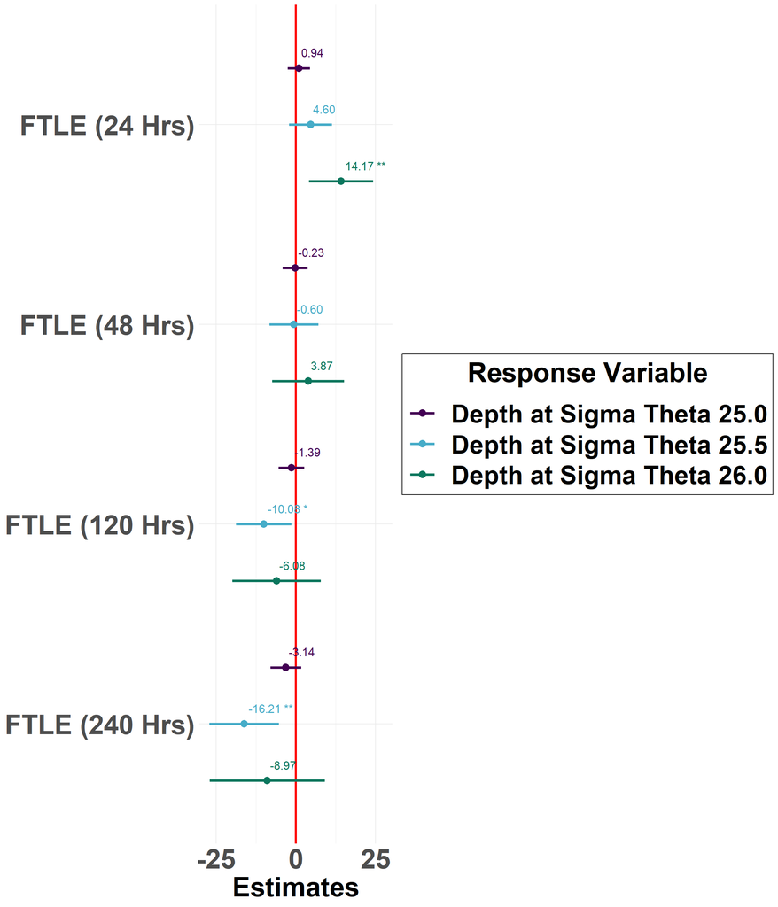

```r
p_ctdSigmathetaAll <- plot_models(Sigma26_GLMM24,Sigma26_GLMM48,
                                    Sigma26_GLMM120,Sigma26_GLMM240,
                                    Sigma25_5_GLMM24,Sigma25_5_GLMM48,
                                    Sigma25_5_GLMM120,Sigma25_5_GLMM240,
                                    Sigma25_GLMM24,Sigma25_GLMM48,
                                    Sigma25_GLMM120,Sigma25_GLMM240,
                                    vline.color = "red",
                                    show.p=TRUE,show.values=TRUE,
                                    spacing = .85, p.shape=FALSE,
                                    show.legend = TRUE, dot.size = 3.5, value.size = 4.5, line.size = 1.25,
                                    axis.labels = c("FTLE (240 Hrs)","FTLE (120 Hrs)","FTLE (48 Hrs)","FTLE (24 Hrs)")) +
    # ggtitle("Depth at Sigma Theta ~ FTLE")+
    scale_y_continuous(breaks=c(-25,0,25), limits = c(-27.5,27.5)) +
    theme_minimal() +
    theme(axis.title = element_text(face="bold", size=30),
          axis.text = element_text( face="bold", size=30),
          plot.title = element_text(face="bold", size=25,hjust = 0.5),
          plot.subtitle = element_text( face="bold", size=20,hjust = 0.5),
          plot.caption = element_text( face="bold", size=12,hjust = 0),
          legend.position = "right",#c(0.785,0.4),
          legend.direction = "vertical",
          legend.key.size = unit(1.2,"cm"),
          legend.background = element_rect(fill="white",color="black"),
          legend.text = element_text(face="bold", size=28),
          legend.title = element_text(face="bold", size=30, hjust = 0.5))

  p_ctdSigmathetaAll$guides$colour$title <- "Response Variable"
  p_ctdSigmathetaAll$data$group <- factor(x = c(rep("Depth at Sigma Theta 26.0",4), rep("Depth at Sigma Theta 25.5",4), rep("Depth at Sigma Theta 25.0",4)), levels = c("Depth at Sigma Theta 26.0","Depth at Sigma Theta 25.5","Depth at Sigma Theta 25.0") )
  p_ctdSigmathetaAll <- p_ctdSigmathetaAll + #c("#3B9AB2", "#78B7C5", "#EBCC2A", "#E1AF00", "#F21A00"),
    scale_color_manual(values=c("Depth at Sigma Theta 26.0" =  "#0B775E",
                                "Depth at Sigma Theta 25.5" =  "#46ACC8",
                                "Depth at Sigma Theta 25.0" =  "#440154FF"
    )
    )
  p_ctdSigmathetaAll
```